# Econometrics: Time Series

Diego López Tamayo [^1]

Based on [MOOC](https://www.coursera.org/learn/erasmus-econometrics) by Erasmus University Rotterdam

> “There are two things you are better off not watching in the making: sausages and econometric estimates.” -Edward Leamer

# Time series

## What is a time serie.

Look at [Dates and Times in R Without Losing Your Sanity](https://www.gormanalysis.com/blog/dates-and-times-in-r-without-losing-your-sanity/) to understand how to use correctly date labes in R. Datasets to be used:

```r
revenue <- read_csv(
  "https://raw.githubusercontent.com/diego-eco/diego-eco.github.io/master/downloads/dataset61.csv")
revenue$YEAR<- as.Date(paste0(revenue$YEAR, '-01-01'))

production <- read_csv(
  "https://raw.githubusercontent.com/diego-eco/diego-eco.github.io/master/downloads/dataset62.csv")
# We replace the weird "M" before months.
production <- rename(production, date=`YYYY-MM`)
production$date <- gsub("M","-",production$date)
production$date <- as.Date(as.yearmon(production$date))

dataset_training <- read_csv(
  "https://raw.githubusercontent.com/diego-eco/diego-eco.github.io/master/downloads/trainexer61.csv")
```

Time series data are a specific type of data that need a somewhat special treatment when using econometric methods. The specific aspect of time series variables is that they are sequentially observed. That is, one observation follows after another. The sequential nature of time series observations has important implications for modeling and especially for forecasting and this is different from the cross-sectional data that we have mostly looked at so far.

Think of the shoe size of your next-door neighbor. Now, it is quite unlikely that the very fact that someone lives next to you, implies that this person’s shoe size has predictive value for yours. But with time series data, this is different.

Yesterday’s sales level, likely has predictive value for today’s sales level. Just like last month’s inflation has for current inflation and your last year’s disposable income for this year’s.

A time series variable is observed at a **regular frequency.** This can be once per year, once per month, every day and sometimes, like in some areas of finance, even each millisecond. You can imagine that recent observations on a certain time series variable can have predictive value for future observations. If it is winter-like weather today, it will most likely be so tomorrow. When unemployment is high this month, it probably is still going to be high next month.

So in terms of regression models, you may want to include the past of a variable in order to predict its future. That is, to predict a new observation of $y$, you can use another variable $X$, but you can also think of using $y$ one period lagged. $y(-1)$.

The inclusion of lagged values of the dependent variable in your regression model can also **prevent you from drawing spurious conclusions.** That is, you might think that another variable X helps to predict the variable of interest Y, while in reality, Y one period lagged predicts Y and X is irrelevant.

To illustrate this point consider two variables, X and Y, for which we know that the true data generating process is such that they depend with a factor 0.9 on their own previous value, whereas the variables X and Y are completely uncorrelated.

$$x_t=1+0.9x_{t-1}+\epsilon_{x,t} \space \space \text{ and } \space \space y_t=2+0.9y_{t-1}+\epsilon_{y,t}$$
$$\text{ Two series completely uncorrelated } E(\epsilon_{y,t},\epsilon_{x,s})=0 \space \forall t,s$$

A scatter of simulated Y and X variables with 100 observations may look like this.

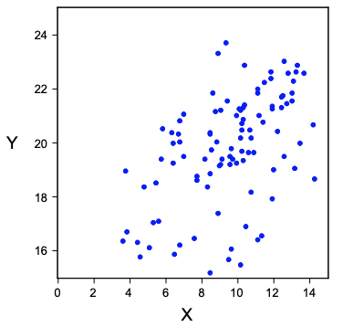

Note that there seems to be some positive connection between the two, while we know that they are completely uncorrelated. You could be tempted to fit a simple regression model. Now suppose you would do so.

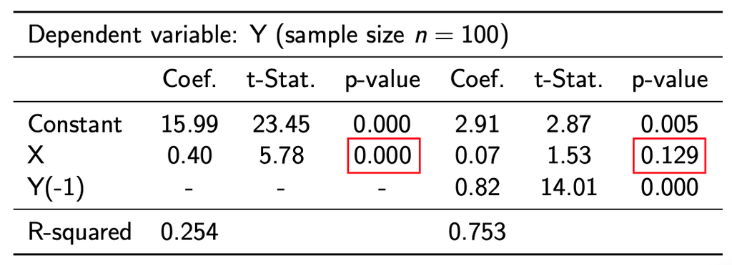

At the left-hand side of this table, you see that we estimate the slope parameter to be equal to 0.4 with a p-value of 0.000. So, this suggests that X has predictive value for Y. Now we know of course, this cannot be true given the way we created the data. The right-hand panel of the table shows what happens if we also include the Y variable one period lagged. The coefficient for this lagged variable is 0.82 and it is significant, whereas the coefficient of X is close to 0 and not statistically significant anymore.

You may now wonder whether we should have included not only X, but also X one period lagged. Consider the regression model where Y depends on Y one period lagged, X and also X one period lagged. Do X and its lag have any predictive power?

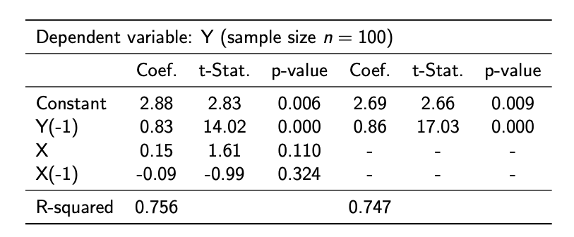

- Use F-test $F = \frac{(R_1^2 - R_0^2)/g}{(1-R_1^2)/(n-k)} \sim F_{(g,n-k)}$
- Number of restrictions: $g = 2$
- number of observations: $n = 100$
- number of parameters unrestricted model: $k = 4$
- values of R-squared: Unrestricted: $R^2_1 = 0.756$ and Restricted: $R^2_0 = 0.747$
- Substitute these values in formula for F-test: $F=1.8 < 3.1$
- Joint effect of $X$ and $X(-1)$ on $Y$ is not significant

The larger model contains two extra variables, so the number of restrictions is two. We have 100 observations and the full model has 4 variables. The two R-squared values were reported in the table. Substituting these values in the familiar expression for the F-test gives a value of 1.8, which is smaller than the 5% critical value of 3.1. So even when we include X and one period lagged X, then these variables do not help to predict Y. Recall that the scatter of Y versus X was very suggestive, but proper analysis shows that pictures can sometimes fool us.

### Example Airline revenue

**Dataset: revenue**

Simulated data set on yearly revenue passenger kilometers, 1975-2015 (estimation period 1976-2015, with pre-sample value for 1975).

- RPK1: Revenue Passenger Kilometers of company 1 (1975-2015)
- RPK2: Revenue Passenger Kilometers of company 2 (1975-2015)
- X1: log(RPK1) (1975-2015)
- X2: log(RPK2) (1975-2015)
- DX1: first difference of X1, growth rate of RPK1 (1976-2015)
- DX2: first difference of X2, growth rate of RPK2 (1976-2015)
- Year: calendar year

Let us now look at how time series in economics and business can look like. Here is an example of passenger revenue data for an airline. The variable of interest is revenue passenger kilometers, which is the sum total over one year of the distance in kilometers traveled by each passenger on each flight of this airline company.

The left-hand graph gives the actual total number of kilometers traveled. The middle graph is obtained when taking natural logs and the right-hand graph shows the yearly growth rates.

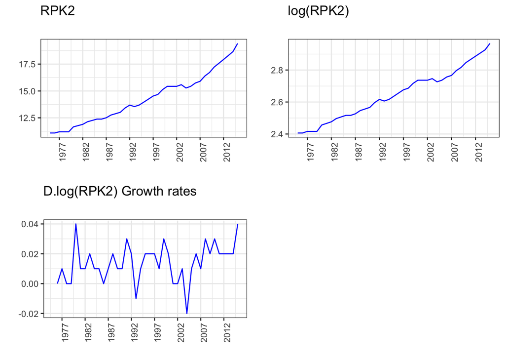

```r
# We create the log and the growth rate of both series
revenue <- revenue %>% mutate(X1=log(RPK1),DX1=c(NA,diff(log(RPK1))),X2=log(RPK2),DX2=c(NA,diff(log(RPK2))))

plot_a <- ggplot(data=revenue, aes(x=YEAR)) +
  geom_line(aes(y=RPK2),col="blue") +
  labs(x = "", y = "", title = "RPK2",
       subtitle = ("")) +
    scale_x_date(date_breaks = "5 year", date_labels = "%Y") +
  theme_bw() +
  theme(axis.text.x = element_text(angle = 90, hjust = 1),
        legend.position = c(.5, .20),
        legend.background = element_rect(fill = "transparent")) +
  scale_color_brewer(name= NULL, palette = "Dark2")

plot_b <- ggplot(data=revenue, aes(x=YEAR)) +
  geom_line(aes(y=X2),col="blue") +
  labs(x = "", y = "", title = "log(RPK2)",
       subtitle = ("")) +
    scale_x_date(date_breaks = "5 year", date_labels = "%Y") +
  theme_bw() +
  theme(axis.text.x = element_text(angle = 90, hjust = 1),
        legend.position = c(.5, .20),
        legend.background = element_rect(fill = "transparent")) +
  scale_color_brewer(name= NULL, palette = "Dark2")

plot_c <- ggplot(data=revenue, aes(x=YEAR)) +
  geom_line(aes(y=DX2),col="blue") +
  labs(x = "", y = "", title = "D.log(RPK2) Growth rates",
       subtitle = ("")) +
    scale_x_date(date_breaks = "5 year", date_labels = "%Y") +
  theme_bw() +
  theme(axis.text.x = element_text(angle = 90, hjust = 1),
        legend.position = c(.5, .20),
        legend.background = element_rect(fill = "transparent")) +
  scale_color_brewer(name= NULL, palette = "Dark2")

grid.arrange(plot_a, plot_b, plot_c, nrow = 2)
```

- $RPK$: Revenue Passenger Kilometers (in billions) yearly totals 1976-2015, trend somewhat exponential
- $log(RPK)$: more linear trend
- $D.log(RPK)=log(RPK_t)-log(RPK_{t-1}) \approx \frac{RPK_t-RPK_{t-1}}{RPK_{t-1}}$ yearly growth rate of RPK

The raw data on the left seems somewhat exponentially increasing, whereas the trend for the log of the time series seems more linear. The yearly growth rates fluctuate between minus 2% and plus 4%. The two leftmost graphs show that the data have a pronounced upward trend. When this occurs, it is not reasonable to assume that the mean of the data is constant over time. In fact, the mean increases with each new observation.

This issue of trends is even more important when two time series show similar trending behavior. Look at this graph that depicts the revenue passenger kilometers of two airlines.

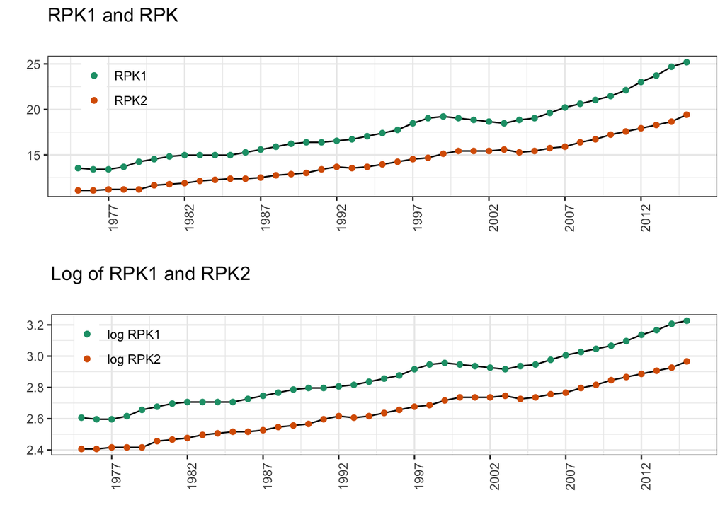

```r
plot_d <- ggplot(data=revenue, aes(x=YEAR)) +
  geom_line(aes(y=RPK2)) + geom_point(aes(y=RPK2,col="RPK2")) +
  geom_line(aes(y=RPK1)) + geom_point(aes(y=RPK1,col="RPK1")) +
  labs(x = "", y = "", title = "RPK1 and RPK",
       subtitle = ("")) +
    scale_x_date(date_breaks = "5 year", date_labels = "%Y") +
  theme_bw() +
  theme(axis.text.x = element_text(angle = 90, hjust = 1),
        legend.position = c(.1, .8),
        legend.background = element_rect(fill = "transparent")) +
  scale_color_brewer(name= NULL, palette = "Dark2")

plot_e <- ggplot(data=revenue, aes(x=YEAR)) +
  geom_line(aes(y=X2)) + geom_point(aes(y=X2,col="log RPK2")) +
  geom_line(aes(y=X1)) + geom_point(aes(y=X1,col="log RPK1")) +
  labs(x = "", y = "", title = "Log of RPK1 and RPK2",
       subtitle = ("")) +
    scale_x_date(date_breaks = "5 year", date_labels = "%Y") +
  theme_bw() +
  theme(axis.text.x = element_text(angle = 90, hjust = 1),
        legend.position = c(.1, .8),
        legend.background = element_rect(fill = "transparent")) +
  scale_color_brewer(name= NULL, palette = "Dark2")

grid.arrange(plot_d, plot_e, nrow = 2)
```

Clearly, they seem to have the same trend, especially when you take logs. This feature can be useful for forecasting in the following way. You may use both time series to estimate the common trend, then you can forecast the trend. And finally, derive the individual forecast for each of the airlines. In case of a single or univariate time series, you can use its own past to make forecasts. When you have several or multivariate time series like in this example, you can try to use the other series to improve your forecasts.

### Example Industrial Production

**Dataset: production**

Data set on Industrial Production and the Composite Leading Index for the USA, monthly data Jan 1985 - Dec 2007 (Source: Conference Board, USA). Estimation period is Jan 1986 - Dec 2005 (pre-sample values in 1985). Forecast evaluation period is Jan 2006 - Dec 2007.

- CLI: Composite Leading Index (based on 10 leading indicators)
- IP: Industrial Production (index, seasonally adjusted)
- LOGCLI: logarithm of CLI
- LOGIP: logarithm of IP
- GRCLI: monthly growthrate of CLI, first difference of LOGCLI
- GRIP: monthly growthrate of IP, first difference of LOGIP

Here is another pair of time series that are clearly related over time. These are the monthly industrial production index for the United States of America and the so-called **[composite leading indicator or CLI.](https://www.oecd.org/sdd/compositeleadingindicatorsclifrequentlyaskedquestionsfaqs.htm)**

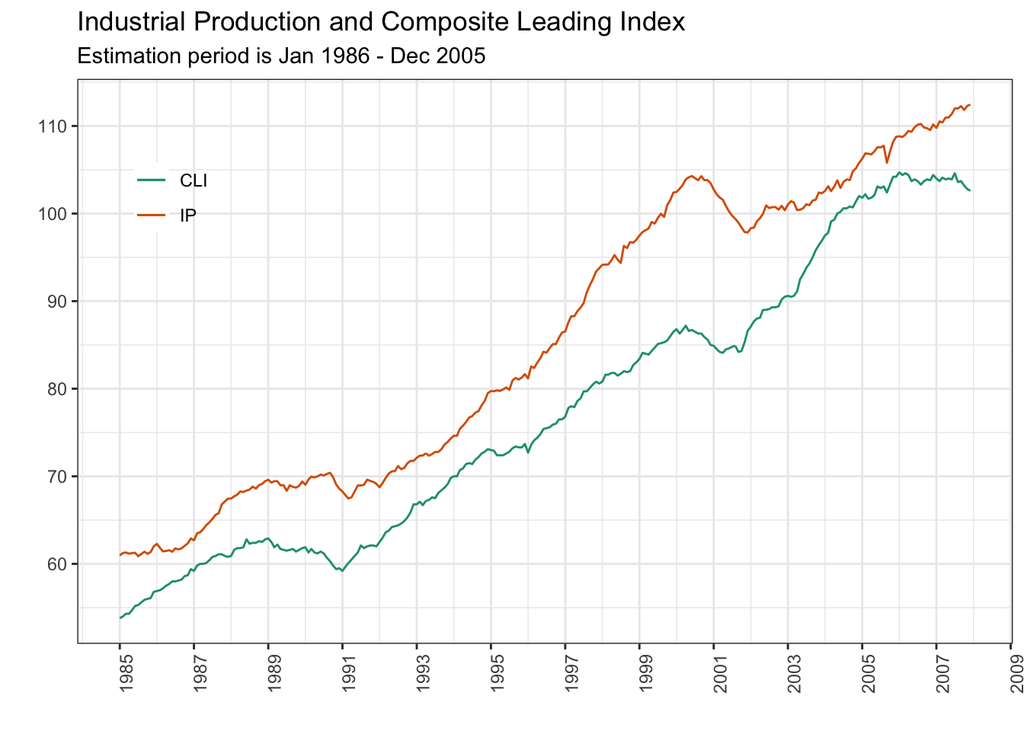

```r
plot_f <- ggplot(data=production, aes(x=date)) +
  geom_line(aes(y=IP,col="IP")) +
  geom_line(aes(y=CLI,col="CLI")) +
  labs(x = "", y = "", title = "Industrial Production and Composite Leading Index ",
       subtitle = ("Estimation period is Jan 1986 - Dec 2005")) +
    scale_x_date(date_breaks = "2 year", date_labels = "%Y") +
  theme_bw() +
  theme(axis.text.x = element_text(angle = 90, hjust = 1),
        legend.position = c(.1, .8),
        legend.background = element_rect(fill = "transparent")) +
  scale_color_brewer(name= NULL, palette = "Dark2")
plot_f
```

The CLI is constructed by The Conference Board based on a set of ten variables like manufacturer’s new orders, stock prices and consumer expectations. All these variables are forward looking. And therefore, they are believed to have predictive value for future macroeconomic developments. And for that reason, it may be useful to consider the CLI in case you want to forecast a variable like industrial production.

As with the airlines, the trends in industrial production and the Composite Leading Index seem to follow a similar pattern, which here associates with the business cycle. In our last section on time series, you will see if industrial production can indeed be predicted by means of this index.

### Example spurious regression

**Dataset: dataset_training**

- epsx: sample of 250 values from normally and independently white noise with mean 0 and variance 1 (independent of $\epsilon_{yt}$)
- epsy: sample of 250 values from normally and independently distributed white noise with mean 0 and variance 1 (independent of $\epsilon_{xt}$)
- x: random walk generated from epsx: $x_{1} = 0$, and $x_{t} = x_{t-1} + \epsilon_{xt}$
- y: random walk generated from epsy: $y_{1} = 0$, and $y_{t} = y_{t-1} + \epsilon_{yt}$

The datafile contains values of four series of length 250. Two of these series are uncorrelated [white noise](https://en.wikipedia.org/wiki/White_noise) series denoted by $\epsilon_{x,t}$ and $\epsilon_{y,t}$ where both variables are $NID(0,1)$ and $E(\epsilon_{y,t},\epsilon_{x,s})=0 \space \forall t,s$. The other two series are so-called [random walks](https://en.wikipedia.org/wiki/Random_walk) constructed from these two white noise series by $x_{t} = x_{t-1} + \epsilon_{xt}$ and $y_{t} = y_{t-1} + \epsilon_{yt}$.

As $\epsilon_{xt}$ and $\epsilon_{yt}$ are independent for all values of $t$ and $s$, the same holds true for all values of $x_{t}$ and $y_{t}$ The purpose of this exercise is to experience that, nonetheless, the regression of $y$ on $x$ indicates a highly significant relation between $y$ and $x$ if evaluated by standard regression tools. This kind of result is called **spurious regression** and is caused by the trending nature of the variables x and y.

- 1. Graph the time series plot of $x_t$ against time t, the time series plot of $y_t$ against time t, and the scatter plot of $y_t$ against $x_t$. What conclusion could you draw from these three graphs?

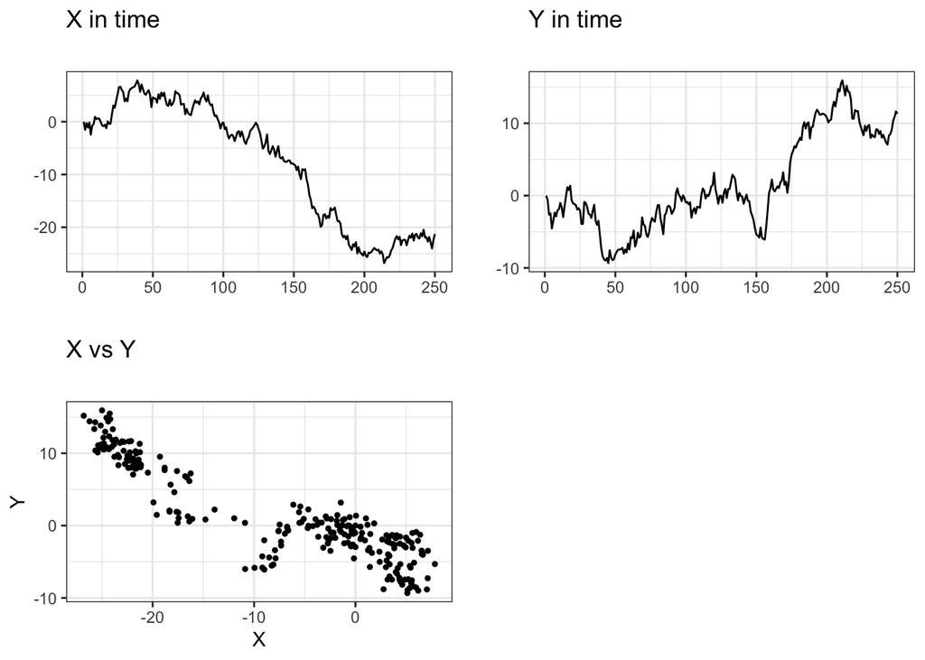

```r
# We add an index column to the dataset for the time t
dataset_training <- dataset_training %>% mutate(time = row_number())
plot_1 <- ggplot(data=dataset_training, aes(x=time)) +
  geom_line(aes(y=X)) +
  labs(x = "", y = "", title = "X in time",
       subtitle = ("")) +
  theme_bw() +
  theme(legend.background = element_rect(fill = "transparent")) +
  scale_color_brewer(name= NULL, palette = "Dark2")
plot_2 <- ggplot(data=dataset_training, aes(x=time)) +
  geom_line(aes(y=Y)) +
  labs(x = "", y = "", title = "Y in time",
       subtitle = ("")) +
  theme_bw() +
  theme(legend.background = element_rect(fill = "transparent")) +
  scale_color_brewer(name= NULL, palette = "Dark2")
plot_3 <- ggplot(data=dataset_training, aes(x=X,y=Y)) +
  geom_point(shape=20) +
  labs(x = "X", y = "Y", title = "X vs Y",
       subtitle = ("")) +
  theme_bw() +
  theme(legend.background = element_rect(fill = "transparent")) +
  scale_color_brewer(name= NULL, palette = "Dark2")
grid.arrange(plot_1, plot_2, plot_3, nrow = 2)
```

The two variables X,Y have completly random movements up and down. And the scatter plot seems to have a negative relation, so we could use X to forecast Y, but we know that this is not the case, the scatterplot is **misleading** in this sense.

- 2. To check that the series $\epsilon_{xt}$ and $\epsilon_{yt}$ are uncorrelated, regress $\epsilon_{yt}$ on a constant and $\epsilon_{xt}$. Report the t-value and p-value of the slope coefficient.

We use the [summ() function](https://cran.r-project.org/web/packages/jtools/vignettes/summ.html) to output our regression.

```r
lm1 <- lm(EPSY ~ EPSX, data=dataset_training)
summ(lm1, digits = 3)
```

| Observations | 250 |
| --- | --- |
| Dependent variable | EPSY |
| Type | OLS linear regression |

| F(1,248) | 1.736 |
| --- | --- |
| R² | 0.007 |
| Adj. R² | 0.003 |

|  | Est. | S.E. | t val. | p |
| --- | --- | --- | --- | --- |
| (Intercept) | 0.031 | 0.064 | 0.484 | 0.629 |
| EPSX | -0.088 | 0.067 | -1.318 | 0.189 |

Standard errors: OLS

The t-value of the coefficient is around -1.32 and the p-value around 0.19, this shows that $\epsilon_{xt}$ and $\epsilon_{yt}$ have no significant relation.

- 3. Extend the analysis of part (b) by regressing $\epsilon_{yt}$ on a constant, $\epsilon_{xt}$, and three lagged values of $\epsilon_{yt}$ and of $\epsilon_{xt}$. Perform the F-test for the joint insignificance of the seven parameters of $\epsilon_{xt}$ and the three lags of $\epsilon_{xt}$ and $\epsilon_{yt}$. Report the degrees of freedom of the F-test and the numerical outcome of this test, and draw your conclusion. Note: The relevant 5% critical value is 2.0.

```r
lm2 <- lm(EPSY ~ lag(EPSY,1) + lag(EPSY,2) + lag(EPSY,3) + EPSX + lag(EPSX,1) + lag(EPSX,2) + lag(EPSX,3), data=dataset_training)
summ(lm2, digits = 3)
```

| Observations | 247 (3 missing obs. deleted) |
| --- | --- |
| Dependent variable | EPSY |
| Type | OLS linear regression |

| F(7,239) | 0.546 |
| --- | --- |
| R² | 0.016 |
| Adj. R² | -0.013 |

|  | Est. | S.E. | t val. | p |
| --- | --- | --- | --- | --- |
| (Intercept) | 0.046 | 0.066 | 0.698 | 0.486 |
| lag(EPSY, 1) | 0.025 | 0.064 | 0.387 | 0.699 |
| lag(EPSY, 2) | -0.016 | 0.065 | -0.244 | 0.807 |
| lag(EPSY, 3) | -0.047 | 0.064 | -0.734 | 0.464 |
| EPSX | -0.097 | 0.069 | -1.405 | 0.161 |
| lag(EPSX, 1) | 0.020 | 0.070 | 0.284 | 0.777 |
| lag(EPSX, 2) | -0.060 | 0.070 | -0.857 | 0.392 |
| lag(EPSX, 3) | 0.009 | 0.068 | 0.138 | 0.890 |

Standard errors: OLS

The $H_0:\gamma_1=\gamma_2=\gamma_3=\gamma_4=\gamma_5=\gamma_6=\gamma_7=0$ and the degrees of freedom of [F test](https://diego-eco.github.io/files/econometrics_simple_multiple.html#statistical_tests) $df=(g,n-k)$ where $g$ is the number of parameter restrictions on the null, $n$ is the number of observations and $k$ is the number of variables in the unrestricted model. In this case we have:

- $g=7$ All 7 restrictions equal to 0.
- $n=247$ Because 3 observarions are lost because the 3 lag values, so the first available observation is in $t=4$.
- $k=8$ Due to the 7 coefficient plus the constant term.

We can see the F-statistic at the top of the output or calculate it by hand $F = \frac{(R_1^2 - R_0^2)/g}{(1-R_1^2)/(n-k)} \sim F_{(g,n-k)}$ where $R^2_0=0$ because is a model with only a constant term. $F=0.55$ and as is smaller of the critical value of 2. We do NOT reject the $H_0$. This is correct as the value of $\epsilon_{yt}$ is independent of all other observations.

- 4. Regress y on a constant and x. Report the t-value and p-value of the slope coefficient. What conclusion would you be tempted to draw if you did not know how the data were generated?

```r
lm3 <- lm(Y ~ X, data=dataset_training)
summ(lm3, digits = 3)
```

| Observations | 250 |
| --- | --- |
| Dependent variable | Y |
| Type | OLS linear regression |

| F(1,248) | 1090.611 |
| --- | --- |
| R² | 0.815 |
| Adj. R² | 0.814 |

|  | Est. | S.E. | t val. | p |
| --- | --- | --- | --- | --- |
| (Intercept) | -2.487 | 0.214 | -11.606 | 0.000 |
| X | -0.515 | 0.016 | -33.024 | 0.000 |

Standard errors: OLS

It seems by looking at the large t-value of X that X has a relevant explanatory power over Y. We know that this is not the case, so the regression is misleading, due to the trending nature of both variables. Look again at the scatterplot of a), it happens that X moves downward for long periods as Y moves upwards for long periods. This is why it seems to be a negative relation.

- 5. Let $e_t$ be the residuals of the regression of part (d). Regress $e_t$ on a constant and the one-period lagged residual $e_{t-1}$. What standard assumption of regression is clearly violated for the regression in part (d)?

```r
# We add the residuals of lm3 into the dataset
dataset_training <- dataset_training %>% mutate(lm3.res = resid(lm3))
lm4 <- lm(lm3.res ~ lag(lm3.res,1), data=dataset_training)
summ(lm4, digits = 3)
```

| Observations | 249 (1 missing obs. deleted) |
| --- | --- |
| Dependent variable | lm3.res |
| Type | OLS linear regression |

| F(1,247) | 1457.056 |
| --- | --- |
| R² | 0.855 |
| Adj. R² | 0.854 |

|  | Est. | S.E. | t val. | p |
| --- | --- | --- | --- | --- |
| (Intercept) | 0.001 | 0.067 | 0.008 | 0.993 |
| lag(lm3.res, 1) | 0.925 | 0.024 | 38.171 | 0.000 |

Standard errors: OLS

This coefficient is significant at 99%, this shows that the residuals are very strongly correlated. Therefore violates the [standar regression assumption A7](https://diego-eco.github.io/files/econometrics_simple_multiple.html#statistical_tests) that the error terms should be uncorrelated.

## Representing time series

Time series models typically are constructed with two main objectives. First, we want to describe the key properties of the time series data. In particular, the nature of the trend and the correlations with past values. And second, we may want to exploit these features to make forecasts of future observations.

The time series of interest is denoted as y, with the subscript t indicating the observation in period t. n refers to the number of available observations, or the length of the time series.

$$\begin{split}
\text{Time serie : } & \\
& y_t \space \text{ where } \space t=1,..,n \text{ is the time index.} \\
\end{split}$$
### Stationarity

Let us begin with a very important issue, that of stationarity. A time series y is called **stationary, if its mean, variance, and covariances with past observations are constant over time.** Stationarity is an important condition that needs to be satisfied before we can even start thinking about designing a meaningful model for a given time series. Intuitively, if for each new observation of the time series properties like the mean and variance change, then we cannot reliably model such data, let alone provide reliable forecasts.

$$\begin{split}
y_t \space \text{ is stationary if : } & \\
mean = & E(y_t) = \mu \space \text{ is fixed and same for all t } \\
autocovariance = & E[(y_t-\mu)(y_{t-k}-\mu)]= \gamma_k \space \text{ is same for all t } \\
\end{split}$$

The autocovariances gamma k measure how strongly related observations at different points in time are. In terms of forecasting, they indicate whether past observations can be useful to make predictions of future observations.

Note that when all these autocovariances are zero, then the past carries no predictive value for the future. We call such a time series white noise.

$$\begin{split}
\text{ Special case : } \gamma = k = 0 & \space \forall k \\
& y_t \space \Rightarrow \text{ The time serie is White Noise } \\
\end{split}$$

Note that this relates to [assumption A5 for regression models](https://diego-eco.github.io/files/econometrics_simple_multiple.html#statistical_properties_gauss_markov_theorem). A white noise time series cannot be predicted from its own past, and the only useful prediction is the mean of the variable itself.

$$\textbf{A5. }\text{ Uncorrelated error terms: } E(\epsilon_i \epsilon_j) = 0 \space \forall i \neq j$$

Now this brings us to the **essence of time series modeling**. Our aim is to design a model that distills information from the past for forecasting. The model is deemed successful or adequate, if after all this distillation, there is nothing left that is informative for prediction. That is, the residuals are white noise.

> Purpose of modeling time series: Create a time series model such that residuals are white noise.

In all what follows, we follow the usual convention to write a white noise variable as epsilon.

$$\begin{split}
\text{White noise} & \\
& \text{ Uncorrelated series with mean zero : } \epsilon_t \\
\end{split}$$

### Autoregressive model

Sometimes we call this $\epsilon_t$ the error but we also use the word **shock** to indicate that epsilon is something new to the variable y. A simple and popular time series model is the **autoregressive model**. An autoregression of order 1, or briefly **AR(1)**, is a model where the current observation of y in period t is explained by the previous observation of y in period t minus 1. This simple model provides a nice way to illustrate the relevance of stationarity.

$$\textbf{ AR(1) } y_t = \alpha + \beta y_{t-1}+\epsilon_t$$

If the slope parameter $\beta$ lies between -1 and +1, the effects of past shocks $\epsilon_t$ die out. So, the more distant in the past, the less impact those shocks have on current values of the variable $y_t$. This is a typical property of a stationary time series.

$$\textbf{ Stationarity if } -1 < \beta < 1$$
$$y_t = \alpha + \beta y_{t-1}+\epsilon_t = \alpha + \beta(\alpha + \beta y_{t-2}+\epsilon_{t-1}) +\epsilon_t$$
$$y_t = \alpha (1+\beta)+\epsilon_t + \beta\epsilon_{t-1} + \beta^2y_{t-2} = \alpha (1+\beta)+\epsilon_t + \beta\epsilon_{t-1} + \beta^2(\alpha + \beta y_{t-3}+\epsilon_{t-2}) = ...$$
$$y_t = \alpha \sum^{t-2}_{j=0}\beta^j+\sum^{t-2}_{j=0}\beta^j\epsilon_{t-j}+\beta^{t-1}y_1$$
$$\text{For } t\rightarrow \infty \text{ we get } \beta^{t-1}y_1 \rightarrow 0 \text{ and } y_t=\frac{\alpha}{(1-\beta)\sum^{\infty}_{j=0}\beta^j\epsilon_{t-j}}$$

Later, we will see that stationarity is lost if beta is equal to 1. The first order autoregression assumes that current y can be predicted by 1 period lagged y, but of course it might also be that 1 period lagged y and also 2 period lagged y are useful for predicting the current observation.

$$\textbf{ AR(2) } y_t = \alpha + \beta_1 y_{t-1} + \beta_2 y_{t-2}+\epsilon_t$$

In fact, the number of lags can run up to p, giving rise to the so-called AR(p) model.

$$\textbf{ AR(p) } y_t = \alpha + \beta_1 y_{t-1} + \beta_2 y_{t-2} +... + + \beta_p y_{t-p}+\epsilon_t$$

Consider again the autoregression of order 1, where the current value of the white noise series epsilon is uncorrelated with the past of y.

$$\begin{split}
\textbf{ AR(1) } y_t = \alpha + \beta y_{t-1}+\epsilon_t & \\
& \epsilon_t \text{ uncorrelated with } y_{t-k} \space \forall k \\
\end{split}$$

If $\beta=1$ then $y_t$ can not be stationary because:

- If $\alpha \neq 0$ and $\beta=1$, then $y_t$ cannot have a fixed mean.

When the intercept alpha is not 0, then the mean will change by alpha for every new observation.
$$E(\epsilon_t) = 0 \text{ so } \mu=E(y_t) = \alpha + E(y_{t-1})+0 = \alpha + \mu \neq \mu$$
- If $\alpha = 0$ and $\beta=1$, then $y_t$ cannot have a fixed variance.

And when the intercept alpha is zero then the variance of the observations increases over time.

$$y_t = y_{t-1}+\epsilon_t \space \text{ so } (y_t-\mu) = (y_{t-1}-\mu) + \epsilon_t \space \text{ uncorrelated.}$$

$$E[(y_t-\mu)^2] = E[(y_{t-1}-\mu)^2] + E[\epsilon_t^2] > E[(y_{t-1}-\mu)^2]$$

### Moving average model

Another useful time series model includes past shocks as explanatory variable. When you look at the epsilons as forecast errors, you can learn from these errors by taking them into account when making new forecasts. The so called **first order moving average model, or MA(1)**, includes epsilon 1 period lagged.

$$\textbf{ MA(1) } y_t = \alpha + \epsilon_t +\gamma \epsilon_{t-1}$$

As $\epsilon_t$ is uncorrelated with it’s own past and future, this model implies that $y_t$ is correlated with $y_{t-1}$ period lagged but not with more distant lags. $y_{t-k}$ for $k=2,3...$

We can generalize this model to a moving average model of order q, which includes q lag forecast errors.

$$\textbf{ MA(q) } y_t = \alpha + \epsilon_t + \gamma_1 \epsilon_{t-1} + ... + +\gamma_q \epsilon_{t-q}$$

### ARMA model

It is also possible to combine the two models, which gives rise to an ARMA(1,1), if p and q are both equal to 1, or an ARMA(p,q), if these orders take different values.

$$\textbf{ ARMA(p,q) } y_t = \alpha + \beta_1 y_{t-1} + \beta_2 y_{t-2} +... + \beta_p y_{t-p}+\epsilon_t + \gamma_1 \epsilon_{t-1} + ... + +\gamma_q \epsilon_{t-q}$$

### Two autoregressive equations.

Moving average (MA) terms may arise when two autoregressive processes are related. Let $\epsilon_{x,t}$ and $\epsilon_{y,t}$ be be two mutually independent white noise processes, and let $y_t=\gamma x_t+\epsilon_{y,t}$ and $x_t=\delta x_{t-1}+\epsilon_{x,t}$. We can derive the orders p and q for the ARMA model for $y_t$ (that does not include $x_t$).

- Consider that $y_t - \delta y_{t-1}=\gamma (x_t- \delta x_{t-1})+ \epsilon_{y,t} - \delta \epsilon_{y,t-1}$
- So we can express
  $$y_t = \delta y_{t-1} + \gamma\epsilon_{x,t} + \epsilon_{y,t} - \delta \epsilon_{y,t-1}$$
  Notice that this is an AR(1) order proces p=1, and error $w_t=\gamma\epsilon_{x,t} + \epsilon_{y,t} - \delta \epsilon_{y,t-1}$ is a MA(1) because $E(w_tw_{t-1})=-\delta Var(\epsilon_{y,t-1})$ and $E(w_tw_{t-2})=E(w_tw_{t-3})=E(w_tw_{t-4})=...=0$

We see that now y depends on y 1 period lagged, on the shock to x, the shock to y and, this is crucial, also the one period lagged shock to y. So the autoregressive order is one, whereas the moving average order is also one. Hence, **correlation, across joint autoregressive time series can lead to individual time series models of the ARMA type.**

### (Partial) Autocorrelation Function

The time series models that we have discussed so far, autoregression and moving average and their combination, imply specific correlation properties of the time series. This relation can be reversed, that is, when you see certain properties of the data in the real world you can decide which model to use. And the **autocorrelation** is a very useful tool for this purpose.

$$\begin{split}
\text{ k-th order sample autocorrelation coefficient : } & \\
ACF_k=cor(y_{t},y_{t-k}) & = \frac{\sum^n_{t=k+1}(y_t-\bar y)(y_{t-k}-\bar y)}{\sum^n_{t=k+1}(y_t-\bar y)^2} \\
\end{split}$$

For example, when the data are generated by a moving average model of order q, then the sample autocorrelations after lag q, will all be close to zero. For example, when the data are generated by a moving average model of order q, then the sample autocorrelations after lag q, will all be close to zero.

- If $y_t$ is MA(q), then $ACF_k \approx 0$ for all $k>q$.

Next to autocorrelations, we also have the concept of **partial autocorrelations.** These account for the fact that the observations of y at time t $y_t$, and at time t minus two $y_{t-2}$, may seem to be correlated due to the fact that they both are related to the observation of y at t minus one $y_{t-1}$.

The sample partial autocorrelations follow from regressions of y on its own past values. If in this regression, the k-th lag coefficient is insignificant for values larger than p, then this suggests to use an AR model of this order p.

- k-th order sample partial autocorrelation coefficient: $PACF_k$ k is the OLS coefficient $b_k$ in regression model:

$$y_t=\alpha + \beta_1 y_{t-1} + ... + \beta_{k-1} y_{k-1} + \beta_k y_{t-k} + \epsilon_k$$
- If $y_t$ is AR(p), then $PACF_k\approx 0$ for all $k>p$. The 95% confidence bounds around autocorrelations and partial autocorrelations are marked by plus and minus two divided by the square root of the sample size n. - 5% critical value: not significant if $-\frac{2}{\sqrt{}n} < (P)ACF < \frac{2}{\sqrt{}n}$.

### Back to airlines example

Let us return now to the airline revenue passenger kilometers data. The data show a trend. And the growth rates do not.

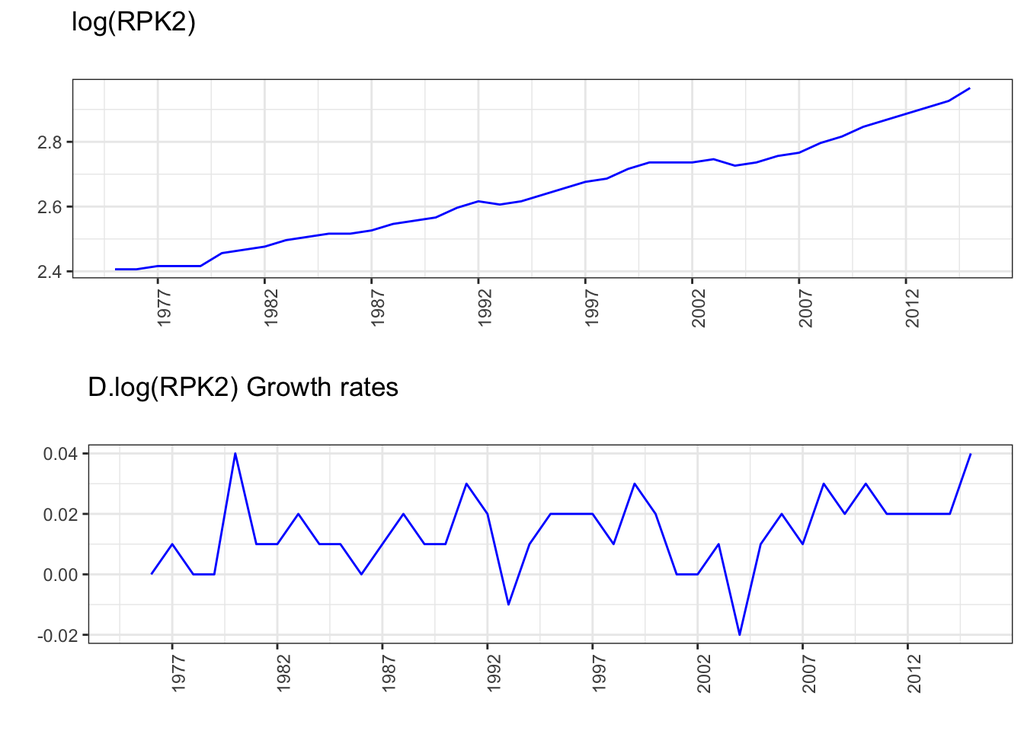

```r
grid.arrange(plot_b, plot_c, nrow = 2)
```

- log(RPK) is not stationary.
- first difference of log(RPK) (yearly growth rate) is stationary.

First we create the [time series object in R](https://www.tutorialspoint.com/r/r_time_series_analysis.htm) And we use use the [library forecast](https://www.statmethods.net/advstats/timeseries.html) to plot the Acf and Pacf

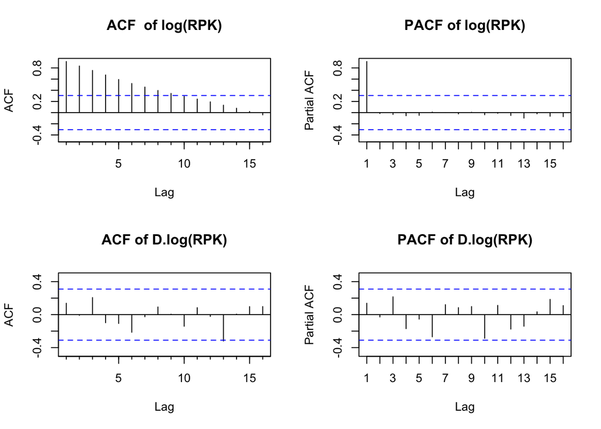

```r
# We create the time series object
ts1 <- ts(revenue[,-1], frequency = 1,start = 1975)
par(mfrow=c(2,2))
Acf(ts1[,4],main = "ACF  of log(RPK)")
Pacf(ts1[,4],main = "PACF of log(RPK)")
Acf(ts1[,6],main = "ACF of D.log(RPK)")
Pacf(ts1[,6],main = "PACF of D.log(RPK)")
```

The autocorrelations of the log series show a very slowly decaying pattern. And the partial autocorrelations are only large at lag 1. The values for the growth rates are not significant, as the number of observations is 39 and 2 divided by the square root of 39 is about 0.3.

### Trends

Next, let us pay attention to the important issue of trends. Several trend models are available.

First, you have what is called a random walk. This is an autoregressive model, but with a slope parameter equal to 1.

$$y_t=y_{t-1}+\epsilon_t \space \space \text{ random walk, stochastic trend, no clear direction}$$

When the intercept alpha is unequal to 0, then we get trending data that looks like the airline’s data, or the industrial production index considered before.

$$y_t=\alpha+y_{t-1}+\epsilon_t \space \space (\alpha \neq 0) :\text{ stochastic trend}$$
When the model also contains a deterministic trend term, beta times t, then you get an explosive trend pattern.

$$y_t=\alpha+ \beta t +y_{t-1}+\epsilon_t \space \space (\beta \neq 0) :\text{ stochastic (explosive) trend}$$
If no lagged value of y is included, this gives a fully deterministic trend model.

$$y_t=\alpha+ \beta t +\epsilon_t \space \space (\beta \neq 0) :\text{ deterministic trend}$$

And if the lagged y term has a parameter smaller than 1, then this still results in a deterministic trend, but without random walk aspects.

$$y_t=\alpha+ \beta t + \gamma y_{t-1} +\epsilon_t \space \space (\beta \neq 0 , \mid \gamma \mid <1) :\text{ deterministic trend}$$
The main notion here, is that a **stochastic trend, that is where the autoregressive parameter is equal to 1**, can only be silenced by transforming the data, by taking their first difference. This is denoted by the symbol Delta.

$$y_t=\alpha+y_{t-1}+\epsilon_t \space \space \text{ then } \Delta y_t=y_t-y_{t-1}=\alpha+\epsilon_t$$

### Example deterministic and stochastic trend

To give you some visual impression of how the parameters in a time series model determine how the data will look like, consider the following graphs of artificially generated data.

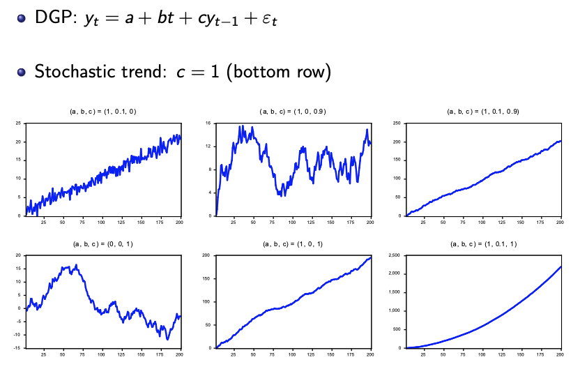

Clearly the parameters matter a lot in how the data look like. This notion will be exploited in the actual analysis of real data. You look at the data and you see certain properties and from these properties, you can get ideas on the models that might be useful to fit and forecast this time series.

### Cointegration

If two time series share the same stochastic trend, we say that they are cointegrated. In the next section, we will consider this in more detail.

- Sometimes: $x_t$ and $y_t$ each have stochastic trend, but $y_t - cx_t$ is stationary for some value of c.
- Cointegration (common stochastic trend)

Suppose that $z_{t}=z_{t-1}+\epsilon_{z,t}$ is unobserved, whereas $x_{t}=\alpha_1 + \gamma_1z_t+\epsilon_{x,t}$ and $y_{t}=\alpha_2 + \gamma_2z_t+\epsilon_{y,t}$ are observed, where $\epsilon_{z,t},\epsilon_{x,t},\epsilon_{y,t}$ are white noise processes. Show that $x_t$ and $y_t$ are cointegrated, and find the value of c for which $y_t - cx_t$ is stationary.

$$\gamma_1y_t-\gamma_2x_t = (\gamma_1\alpha_2-\gamma_2\alpha_1)+(\gamma_1\epsilon_{y,t}-\gamma_2\epsilon_{x,t})$$
Where $\epsilon_t=\gamma_1\epsilon_{y,t}-\gamma_2\epsilon_{x,t}$ is white noise, therefore stationary.

$\gamma_1y_t-\gamma_2x_t=\gamma_1(y_t-\frac{\gamma_2}{\gamma_1}x_t)$ So $c=\frac{\gamma_2}{\gamma_1}$.

We use the fact that y and x share the same stochastic trend z. A specific linear combination of y and x does not include that trend anymore.

### Example of autocorrelation

If $y_t$ is a stationary process with mean $\mu$, then the k-th order autocovariance is defined as $\gamma_k=E[(y_t-\mu)(y_{t-k}-\mu)]$. In particular, the variance is $\gamma_0=E(y_t-\mu)^2$. The k-th order autocorrelation is defined as $\rho_k=\frac{Cov(y_t,y_{t-k})}{Var(y_t)}$.

The AR(1) model is:
$$y_{t}=\alpha+\beta y_{t-1}+\epsilon_t$$
We know $E(\epsilon_t)=0$ and $\epsilon_t$ is uncorrelated with all values of $y_s$ for all $s<t$.

- 1. Show that the mean of the AR(1) model is equal to $\mu=\frac{\alpha}{1-\beta}$

The expected value of $y_t$ is equal to $E(y_{t})=E(\alpha+\beta y_{t-1}+\epsilon_t)=\alpha+\beta E(y_{t-1})+E(\epsilon_t)=\mu=\alpha+\beta \mu + 0$ And that means that $\beta \neq 1$

$$\mu=\frac{\alpha}{1-\beta}$$

- 2. Define $z_t=y_t-\mu$. Show that $z_t=\beta z_{t-1}+\epsilon_t$ and that $Var(z_t)=\frac{\sigma^2}{(1-\beta^2)}$.

In part a) we see that $\alpha=\mu(1-\beta)=\mu-\beta\mu$. If we substitute this in the AR(1) equation we get:

$$y_{t}=\mu-\beta\mu+\beta y_{t-1}+\epsilon_t$$
$$y_{t}-\mu=\beta(y_{t-1}-\mu)+\epsilon_t$$
And as we can define $z_t=y_t-\mu$

$$z_t=\beta z_{t-1}+\epsilon_t$$

The expected value of $E(z_t)=E(y_{t}-\mu)=0$ and the variance of $Var(z_t)=E(z_t-E(z_t))^2=E(z_t^2)$ So if we use the definition of $z_t$ we obtain:

$$Var(z_t)=E(z_t^2)=E((\beta z_{t-1}+\epsilon_t)^2)=\beta^2 E(z_{t-1}^2)+E(\epsilon^2_t)+2\beta E(z_{t-1}\epsilon_t)$$
We use the fact that $E(z_{t-1}\epsilon_t)=0$
$$Var(z_t)=\beta^2 Var(z_{t}^2)+\sigma^2+0$$
$$Var(z_t)=\frac{\sigma^2}{(1-\beta^2)}$$

That means that that $-1<\beta<1$

- 3. Use the idea of part (b) to show that the autocorrelations of $y_t$ are equal to $\rho_k=\beta^k$

Because $y_t$ and $z_t$ have the same autocovariances, we compute those of $z_t$, it is simplier because the mean of $z_t$ is zero. The first order autocovariance $\gamma_1$
$$\gamma_1=E(z_tz_{t-1})=E(\beta z_{t-1}+\epsilon_t)z_{t-1} = \beta E(z_{t-1}^2) + E(\epsilon_t z_{t-1}) = \beta \gamma_0+0 = \beta \gamma_0$$
Hence the first order autocorrelation is:

$$\rho_1=\frac{\gamma_1}{\gamma_0}=\beta$$
And the second order autovoariance $\gamma_2$ is equal:

$$\gamma_2=E(z_tz_{t-2})=E(\beta z_{t-1}+\epsilon_t)z_{t-2} = \beta E(z_{t-1}z_{t-2}) + E(\epsilon_t z_{t-2}) = \beta \gamma_1+0 = \beta (\beta\gamma_0) = \beta^2\gamma_0$$
Hence the second order autocorrelation is:

$$\rho_2=\frac{\gamma_2}{\gamma_0}=\beta^2$$
And similarly, the k-th order autocovariance is equal to:

$$\gamma_k=E(z_tz_{t-k})=E(\beta z_{t-1}+\epsilon_t)z_{t-k} = \beta E(z_{t-1}z_{t-k}) + E(\epsilon_t z_{t-k}) = \beta \gamma_{k-1}+0 = \beta\gamma_{k-1}$$
Which is equal to:

$$\gamma_k=\beta^k\gamma_0$$
And the k-th order autocorrelation:
$$\rho_k=\frac{\gamma_k}{\gamma_0}=\beta^k$$

- 4. Argue that stationarity requires that $-1<\beta<1$

The correlations are always $-1<\beta<1$ so $\mid \beta \mid \leq 1$, furthermore $\beta=1$ is exclueded in a) and $\beta=-1$ excluded in part b).

## Specification and estimation

In this section, you will learn which steps to take to specify time series models, and to estimate parameters in such models. **Stationarity is crucial here**. And therefore, you should take care of any non-stationarity right at the start. Once a stationary series is obtained after proper transformation, you can use the autocorrelation (AC) and partial autocorrelation (PAC) functions to specify a first-guess model.

We start with the major motivation for using time series, that is, forecasting. Forecasts are based on a model that properly summarizes past information.

$$\text{Past values of time series model} \rightarrow \text{ Model } \rightarrow \text{ Forecast future values}$$
This past information can concern the own past of the dependent variable y, or possibly also the past of an explanatory factor, x. For notational convenience, we use PY and PX to denote this past information.

- In a univariate model, the forecast is based only on the past of the dependent variable y itself.
- And if we use also an explanatory factor x, then the forecast is a function of the past of both x and y.

$$\begin{split}
\text{ Notation : } & \\
y_t & : \text{ time series of interest } (t = 1, . . . , n) \\
x_t & : \text{ time series possible explanatory factor (restrict to one) } \\
Py_{t-1} & : [y_{t-1},y_{t-2},...,y_1]\text{ past information on y at time t } \\
Px_{t-1} & : [x_{t-1},x_{t-2},...,x_1]\text{ past information on x at time t } \\
\\
\text{ Univariate time series forecast model } & : \hat y_t=F(Py_{t-1}) \\
\text{ Forecast model with explanatory factor} & : \hat y_t=F(Py_{t-1},Px_{t-1}) \\
\end{split}$$

Of course, we want to use the past information in an optimal way, such that there is no predictive value anymore in the errors that we make. Indeed, we wish to arrive at a forecast error that is uncorrelated with the information in PY and PX.

- Aim: Optimal use of past information to get best forecasts.
- Wish: Forecast error $\epsilon_t=y_t-\hat y_t$ uncorrelated with past information.

Note that if the forecast error would be predictable, then some relevant information is still missing that could be used to improve the forecast.

### Univariate time series model

Let us start with a univariate time series model. Here the forecast for y is a function of past observations of y only.

$$\text{ Univariate time series forecast model: } : \hat y_t=F(Py_{t-1})$$

Now we first have to decide on the function F. And although many functions F can be chosen, a popular choice is the **linear function**. When the lagged information in PY is limited at lag p, the well-known autoregressive model of order p emerges. AR(p).

The true value of y is the forecast plus an error term that is equal to the forecast error. And together, this gives rise to the AR(p) model.

$$\hat y_t = \alpha + \beta_1 y_{t-1} + \beta_2 y_{t-2} +... + + \beta_p y_{t-p}$$

$$y_t = \hat y_t + \epsilon_t = \alpha + \beta_1 y_{t-1} + \beta_2 y_{t-2} +... + \beta_p y_{t-p}+\epsilon_t$$
Because $\epsilon_t$ is white noise that is, the future values of the epsilons cannot be predicted in a linear way. This can be seen in the following way:

Consider forecasts from an autoregression of order p, which says that there is useful information in the past until, and including, p observations ago $\hat y_t = \alpha + \beta_1 y_{t-1} + \beta_2 y_{t-2} +... + + \beta_p y_{t-p}$. And consider the forecast error epsilon, which should be uncorrelated with the past of y. $\epsilon_t=y_t-\hat y_t$ uncorrelated with uncorrelated with $y_s$ for all s < t.

You can show that, in this situation, the epsilon process is white noise, that is, the future values of the epsilons cannot be predicted in a linear way.

- Without loss of generality, consider case s < t.
- $\epsilon_s=y_s-\alpha-\sum^p_{j=1}\beta_jy_{s-j}$ is a linear function of $y_r$, $r \leq s < t$
- $e_t$ is uncorrelated with $y_r$ for all $r<t$, so also uncorrealted with $\epsilon_s$.

The crucial step here is that **epsilon is a linear function of current and past values of the dependent variable.**

### Estimation of AR and ARMA

To estimate the parameters in an **AR model of order p**, we use the same ideas as in linear regression, where an optimal strategy is to **minimize the sum of squared errors**, which, of course, now are the forecast errors. So, you can use ordinary least squares.

$$\text{ Forecast error: } : \epsilon_t=y_t-\hat y_t =y_t-\alpha-\sum^p_{j=1}\beta_jy_{t-j}$$
$$\textbf{ To minimize via OLS: } : \sum^n_{t=p+1}\epsilon_{t}^2$$

As a moving average model **MA(q) includes also lagged forecast errors that are still unknown before estimation**, we have to resort to the method of **maximum likelihood in case of ARMA models**.

### ADL(p,r) model

The usefulness of least squares extends to the case where the time series model also includes the past of an explanatory factor x. And again, here the popular choice is to use a linear forecast function.

$$\text{ Forecast: } : \hat y_t=F(Py_{t-1},Px_{t-1})$$
$$\text{ find F such that } \space \epsilon_t=y_t-\hat y_t \space \text{ uncorrelated with } Py_{t-1},Px_{t-1}$$
And this model that includes the lags of y and also the lags of x, when there are p lags of y, and r lags of x, we usually call this the autoregressive distributed lag model of order p and r, or shortly **ADL(p,r)**.

$$\text{ ADL(p,r) } : \hat y_t=\alpha + \beta_1 y_{t-1} +... + \beta_p y_{t-p} + \gamma_1x_{t-1} + ...+\gamma_rx_{t-r}$$
Also for this ADL model, we can use the least squares method to estimate the parameters.

$$\textbf{ To minimize via OLS: } : \sum^n_{t=m+1}\epsilon_{t}^2 \space \text{ where m=max(p,r)}$$

### Granger causality

The ADL model is particularly useful to examine what is called [Granger causality](https://en.wikipedia.org/wiki/Granger_causality), named after the Nobel Laureate Sir Clive Granger. This idea of causality builds on the idea of forecastability. That is, when the past of one variable is helpful to predict the future of another, you might consider that as some form of causality.

What you do is to construct two ADL models. One for the variable y, and another for the variable x. Note that both models include the past of the dependent variable itself plus the past of the other variable.

$$y_t=\alpha + \sum^p_{j=1}\beta_jy_{t-j} + \sum^r_{j=1}\gamma_jx_{t-j} +\epsilon_t$$

$$x_t=\alpha^{\ast} + \sum^{p^{\ast}}_{j=1}\beta_j^{\ast}x_{t-j} + \sum^{r^{\ast}}_{j=1}\gamma_j^{\ast}y_{t-j} +\epsilon_t^{\ast}$$

-$x_t$ helps to predict $y_t$ if $\gamma_j\neq 0$ for some j -$y_t$ helps to predict $x_t$ if $\gamma_j^{\ast}\neq 0$ for some j

If some of the gamma parameters in the ADL model for y are different from 0, then the past of x helps to predict the future of y. And vice versa, in case the gamma star parameters are non-zero in the ADL model for x.

In case of such of non-zero parameters, you can say that **one variable is Granger causal to the other**. For example, we may find that x is Granger causal for y, but not the other way around. This indicates that the past of x can be helpful for predicting y. But for forecasting x, only its own past is relevant.

- $x_t$ is Granger causal for $y_t$ if it helps to predict $y_t$, whereas $y_t$ does not help to predict $x_t$.

You can check the significance of, for example, the $\gamma_j^{\ast}$ coefficients in the ADL model for x by means of the familiar F-test. And, conveniently, as these two models only include lag variables, you can still estimate the parameters using least squares for each of the two equations separately.

$$\text{ Test }H_0: \gamma_j^{\ast}=0 \space \forall j=1,...,r^{\ast} \sim F-test$$

### Consequences of non-stationarity

The first thing that needs to be done in modeling is to make sure that the time series you wish to analyze is stationary. The reason that we need stationarity is that this is required for proper statistical analysis. So, one should first somehow test if the variable of interest is stationary.

- [Regression assumption A2](https://diego-eco.github.io/files/econometrics_simple_multiple.html#statistical_properties_gauss_markov_theorem) not satisfied: regressors $y_{t-j}$ are random.
- Standard OLS t- and F-tests hold true in large enough samples provided all variables in equation are stationary.

So, one should first somehow test if the variable of interest is stationary. To do this, we can again make use of a time series model. For example, in the case of an autoregression of order 1, we know that when the parameter is equal to 1, then the time series is not stationary. And this suggests that we can test for stationarity by testing the value of this parameter.

$$\begin{split}
\text{Test for stationarity : } & \\
\textbf{ AR(1) } y_t = \alpha + \beta y_{t-1}+\epsilon_t & \space \text{ test } H_0: \beta=1 \text{ against} H_1: -1 < \beta <1 \\
\end{split}$$

As we are familiar with statistical tests for parameters to be equal to 0, we usually rewrite the AR(1) model by subtracting the one period lagged $y_{t-1}$ from both sides of the equation.

$$\begin{split}
\text{Rewrite AR(1) : } & \\
\Delta y_t & = y_t - y_{t-1} = \alpha + (\beta-1) y_{t-1}+\epsilon_t = \alpha + \rho y_{t-1}+\epsilon_t \\
\text{Where } \rho& = (\beta-1) \\
\end{split}$$

### Unit root test

Now, the $\rho$ parameter can be tested to be equal to 0 using a t-test. As we are interested in the parameter rho being 0, or smaller than 0, we reject non-stationarity when the t- ratio is more negative than minus 2.9. Note, that this is not the usual value of $t_{0.95}=-1.65$. And this is due to the fact that **under the null hypothesis, y is non-stationary, which gives rise to a different statistical theory.**

$$\begin{split}
\text{Test for stationarity : } & \\
\Delta y_t = \alpha + \rho y_{t-1}+\epsilon_t & \space \text{ test } H_0: \rho=0 \text{ against } H_1: \rho < 0 \\
\text{ Reject } & H_0 : \text{non-stationarity if }t_{\hat \rho}<-2.9 \\
\end{split}$$

For an AR(2) model we follow the same process, it is convenient to write the AR(2) model as a mixture of variables in first differences and in levels.

$$\begin{split}
\text{Rewrite AR(2) : } & y_t = \alpha + \beta_1 y_{t-1} + \beta_2 y_{t-2} +\epsilon_t \\
\Delta y_t & = y_t - y_{t-1} = \alpha + (\beta_1-1) y_{t-1} + \beta_2 y_{t-2} + \epsilon_t \\
\text{Sum and substract } & \beta_2y_{t-1}\\
\Delta y_t & = \alpha + (\beta_1+\beta_2-1) y_{t-1} - \beta_2y_{t-1} + \beta_2 y_{t-2} + \epsilon_t \\
\Delta y_t & = \alpha + (\beta_1+\beta_2-1) y_{t-1} - \beta_2(y_{t-1}- y_{t-2}) + \epsilon_t \\
\Delta y_t & = \alpha + (\beta_1+\beta_2-1) y_{t-1} - \beta_2\Delta y_{t-1} + \epsilon_t \\
\text{ we get :}\\
\Delta y_t & = \delta + \rho y_{t-1} + \gamma \Delta y_{t-1} +\epsilon_t \\
\text{Where } & \delta = \alpha , \rho=(\beta_1+\beta_2-1) , \gamma=- \beta_2 \\
\end{split}$$

### Augmented Dickey Fuller

This rewriting of the AR(p) models provides the basis of the so-called [Dickey-Fuller test](https://en.wikipedia.org/wiki/Dickey%E2%80%93Fuller_test). The test equation can either include a deterministic trend, or not, and the choice is usually based on the visual impression of the data.

The inclusion or exclusion of the deterministic trend term, $\beta t$, matters for the relevant 5% critical value. When the trend term is not included, the critical value for the t-test on rho is $t_{\hat \rho}<-2.9$, as we saw before. But when the trend is included, it becomes $t_{\hat \rho}<-3.5$.

$$\begin{split}
\text{If data NO clear trend direction : } & \\
\Delta y_t = \alpha + \rho y_{t-1} + \gamma_1 \Delta y_{t-1} +...+ \gamma_L \Delta y_{t-L} +\epsilon_t \\
\\
\text{Test without deterministic trend} \\
\text{ Reject } H_0 : \text{non-stationarity if } t_{\hat \rho}<-2.9 \\
\end{split}$$

$$\begin{split}
\text{If data has clear trend direction : } & \\
\Delta y_t = \alpha + \beta t+ \rho y_{t-1} + \gamma_1 \Delta y_{t-1} +...+ \gamma_L \Delta y_{t-L} +\epsilon_t \\
\\
\text{Test without deterministic trend} \\
\text{ Reject } H_0 : \text{non-stationarity if } t_{\hat \rho}<-3.5 \\
\end{split}$$

In practice, we decide on the number of lags in the autoregression by testing for correlation in the residuals, or by using a model selection criteria.

- Choice lag L: serial correlation check, or AIC/BIC. See (Partial) Autocorrelation Function.

When the autoregression has more than one lag, the Dickey-Fuller test is usually called the [Augmented Dickey-Fuller](https://en.wikipedia.org/wiki/Augmented_Dickey%E2%80%93Fuller_test) test, abbreviated as ADF.

### Summary

So, now, how should you proceed to specify a time series model?

1. First you perform an ADF test. And when you can reject a unit root, or non-stationarity, this means that $y_t$ is stationary, and you can model the series $y_t$ without further transformation. But when it is not rejected, you should take the first difference, and continue with $\Delta y_t$.
2. Next, you can use OLS to estimate the parameters in an autoregression AR(p), or when you wish to consider an autoregressive distributed lag model ADL(p,r), you perform unit root tests for both series y and x, and proceed with levels or with first differences.

There is, however, one exceptional, and practically relevant case, namely, when y and x are not stationary, **but a linear combination of the two variables is.** When $y_t$ and $x_t$ are cointegrated.

### Cointegration

Two variables are called cointegrated when a linear combination is stationary. This can only occur when $y_t$ and $x_t$ have the same stochastic trend.

$$y_t , x_t \text{ are are cointegrated if both series are non-stationary, but a linear combination is stationary : } y_t-cx_t$$

You might, then, interpret this linear combination $y_t = c x_t$ as the **long-run equilibrium**, which is an attractive concept in economics.

### Test for cointegration

A simple test for cointegration is the [Engle-Granger test](https://en.wikipedia.org/wiki/Error_correction_model#Engle_and_Granger_2-step_approach). This test amounts to regressing $y_t$ on an intercept and $x_t$ to estimate the long-run equilibrium relationship between these variables.

$$\begin{split}
\text{Engle-Granger test : } & \\
\text{Step 1 : } & \text{ OLS in } y_t=\alpha + \beta x_t + \epsilon_t \rightarrow b \text{ and residuals }e_t \\
\text{Step 2 : } & \text{ Cointegrated if ADF test on }e_t \text{ rejects non-stationarity } \\
& \Delta e_t=\alpha + \rho e_{t-1} + \gamma_1 \Delta e_{t-1} +...+ \gamma_L \Delta e_{t-L} +w_t \\
\end{split}$$

The residuals from this regression can then be interpreted as deviations from the equilibrium, and if the equilibrium relation actually exists, that is if $y_t$ and $x_t$ actually are cointegrated, the residuals should be stationary. And this can be examined, again, using the ADF test as before.

Because the test is now applied to residuals instead of an actually observed time series, the distribution of the ADF test is different. The 5% critical value for the relevant t-test is now minus 3.4, or even minus 3.8 if the trend term is included.

$$\begin{split}
\text{Engle-Granger test : } & \\
\Delta e_t=\alpha + (\beta t) + \rho e_{t-1} + \gamma_1 \Delta e_{t-1} +...+ \gamma_L \Delta e_{t-L} +w_t \\
\\
\text{Test (with) or without deterministic trend} \\
\text{ Reject } H_0 : \text{non-stationarity = cointegrated if } t_{\hat \rho}<-3.4 \text{ or } (-3.8) \\
\end{split}$$

In case of cointegration, the ADL model can be written in the so-called [error correction format](https://en.wikipedia.org/wiki/Error_correction_model), which includes lagged difference variables and the stationary linear combination between $y_t$ and $x_t$. The term error correction follows from the notion that deviations from the long-run equilibrium get corrected by the $\beta_1$ parameter in forecasting the changes of $y_t$.

$$\begin{split}
\text{ECM : if } & x_t,y_t \text{ cointegrated, estimate :} \\
\\
\Delta y_t & = \alpha + \beta_1(y_{t-1}-bx_{t-1}) + \beta_2\Delta y_{t-1} + \beta_3 \Delta x_{t-1}+\epsilon_t\\
\\
\text{ Or more lags for } \Delta y_t , \Delta x_t\\
\end{split}$$

### Example: Partial adjustment and Adaptive Expectations

Several types of economic behavior lead to relations with time lags because it takes some time before adjustments to changed conditions take place. As an illustration,consider a company producing consumer goods. Let $y_t$ denote the production volume in month $t$, and let $x_t$ be the total demand volume in that month.

Suppose that the optimal production volume $y_t^{\ast}$ is equal to $y_t^{\ast}=\gamma +\delta x_t$.

As an example, if the company has a market share of 25%, then $\delta=0.25$ could make sense for this company. If demand changes, then it may take some time for the company to increase production, because it will need to arrange for extra capital and labor.

In this scenario, we could use the [partial adjustment (PA) model](https://ekonometrikblog.files.wordpress.com/2019/09/partial-adjustment-model-regression.pdf), the model postulates that

$$y_t=y_{t-1}+\lambda(y_{t-1}^{\ast}-y_{t-1}) + \epsilon_t$$

$$\begin{split}
\text{PA model : } & \\
y_t & = y_{t-1}+\lambda(y_{t-1}^{\ast}-y_{t-1}) + \epsilon_t \\
& \text{ where } 0 \leq \lambda \leq 1 \\
\end{split}$$

If the company is pro-active, it can decide to **base its production on the expected demand volume** $x_{t}^{\ast}$ and to produce the corresponding volume $y_t=\gamma +\delta x_{t}^{\ast}$.

The [adaptive expectations (AE) model](https://ekonometrikblog.files.wordpress.com/2019/09/partial-adjustment-model-regression.pdf) postulates that the expectations are partly adjusted to the previously observed demand volume by means of

$$\begin{split}
\text{AE model : } & \\
x_t^{\ast} & = x^{\ast}_{t-1}+\lambda(x_{t-1}-x_{t-1}^{\ast}) + \epsilon_t \\
& \text{ where } 0 \leq \lambda \leq 1 \\
\end{split}$$

It is assumed that the $\epsilon_t$ in the PA and AE models is white noise.

- 1. Write the partial adjustment model in terms of only the observed variables $y$ and $x$, by eliminating $y_{t}^{\ast}$.What is the type of the resulting model?

First we substitute $y_t^{\ast}=\gamma +\delta x_t$ in the PA model.

$$y_t = y_{t-1}+\lambda(y_{t-1}^{\ast}-y_{t-1}) + \epsilon_t = y_{t-1}+\lambda(\gamma +\delta x_{t-1}-y_{t-1}) + \epsilon_t$$
Which we can rewrite as:

$$y_t = \lambda\gamma+(1-\lambda)y_{t-1}+\lambda\delta x_{t-1}+ \epsilon_t$$

This is an autoregressive distributed lag model (ADL) with AR lag (p=1) and DL lag (r=1).

- 2. Write the adaptive expectations model in terms of only the observed variables $y$ and $x$, by eliminating $x_{t}^{\ast}$.What is the type of the resulting model?

We first rewrite the AD model as

$$\begin{split}
x_t^{\ast} & = x^{\ast}_{t-1}+\lambda(x_{t-1}-x_{t-1}^{\ast}) + \epsilon_t = (1-\lambda)x_{t-1}^{\ast}+\lambda x_{t-1} + \epsilon_t\\
x_t^{\ast}-(1-\lambda)x_{t-1}^{\ast} & = \lambda x_{t-1} + \epsilon_t\\
\end{split}$$

That means that we should replace the left term in order to eliminate the expectation variable $x_t^{\ast}$. We know $y_t=\gamma +\delta x_{t}^{\ast}$ so we could rewrite $\delta x_{t}^{\ast}=y_t-\gamma$.

We get that $\delta(x_t^{\ast}-(1-\lambda)x_{t-1}^{\ast})=y_t-\gamma-(1-\lambda)(y_{t-1}-\gamma)$. And from the previous equation we get:

$$\delta(x_t^{\ast}-(1-\lambda)x_{t-1}^{\ast}) = \delta \lambda x_{t-1}+\delta\epsilon_t$$
Hence:
$$y_t-\gamma-(1-\lambda)(y_{t-1}-\gamma) = \delta \lambda x_{t-1}+\delta\epsilon_t$$
Equivalently:
$$y_t = \gamma-(1-\lambda)\gamma+(1-\lambda)y_{t-1} + \delta \lambda x_{t-1}+\delta\epsilon_t$$
$$y_t = \gamma\lambda + (1-\lambda) y_{t-1} + \delta \lambda x_{t-1}+\delta\epsilon_t$$

So again we can see that we get an an autoregressive distributed lag model (ADL) with AR lag (p=1) and DL lag (r=1).

- 3. What is the condition for stability of the two models in parts a) and b)? Provide an economic interpretation of this condition.

The condition is that $-1 < (1-\lambda) < 1$, that is $0 < \lambda < 2$. We already assumed that $0 < \lambda < 1$, so the condition for stability is that $\lambda \neq 0$.

If $\lambda=0$ we can see that production is not adjusted in any systematic way in the PA model. Furthermore, we can see that expectations are not adjusted with realized demand in the AE model.

- 4. Consider the AE model based on the last two observed sales volumes, where $x_t^{\ast}=x^{\ast}_{t-1}+\lambda_1(x_{t-1}-x_{t-1}^{\ast})+\lambda_2(x_{t-2}-x_{t-2}^{\ast}) + \epsilon_t$. Write this model in terms of only the observed variables $y$ and $x$, by eliminating $x_{t}^{\ast}$.What is the type of the resulting model?

Similiar to part b) we first rewrite the AE model:

$$\begin{split}
x_t^{\ast} & = x^{\ast}_{t-1}+\lambda_1(x_{t-1}-x_{t-1}^{\ast})+\lambda_2(x_{t-2}-x_{t-2}^{\ast}) + \epsilon_t \\
x_t^{\ast} & = (1-\lambda_1)x_{t-1}^{\ast}-\lambda_2x_{t-2}^{\ast}+\lambda_1x_{t-1} + \lambda_2x_{t-2} + \epsilon_t \\
x_t^{\ast} - (1-\lambda_1)x_{t-1}^{\ast} + \lambda_2x_{t-2}^{\ast} & = +\lambda_1x_{t-1} + \lambda_2x_{t-2} + \epsilon_t \\
\end{split}$$

from $y_t=\gamma +\delta x_{t}^{\ast} \rightarrow \delta x_{t}^{\ast}=y_t-\gamma$ we get the following two substitutions:

$$- (1-\lambda_1)\delta x_{t-1}^{\ast} = - (1-\lambda_1)(y_{t-1}-\gamma)$$
and

$$\lambda_2 \delta x_{t-2}^{\ast} = \lambda_2 \delta (y_{t-2}-\gamma)$$

Using these two terms for the above left side we get:

$$\delta (x_t^{\ast} - (1-\lambda_1)x_{t-1}^{\ast}+\lambda_2x_{t-2}^{\ast}) = y_t -\gamma - (1-\lambda_1)(y_{t-1}-\gamma) +\lambda_2(y_{t-2}-\gamma)$$

We can simplify the left side as follows:

$$\delta (\lambda_1x_{t-1}+\lambda_2 x_{t-2}+\epsilon_t) = y_t -\gamma - (1-\lambda_1)(y_{t-1}-\gamma) +\lambda_2 (y_{t-2}-\gamma)$$

$$\delta\lambda_1x_{t-1}+\delta\lambda_2 x_{t-2}+\delta\epsilon_t = y_t -\gamma - (1-\lambda_1)y_{t-1}+(1-\lambda_1)\gamma +\lambda_2 y_{t-2}-\lambda_2\gamma$$
We can rewrite so that:

$$\begin{split}
y_t & = \gamma - (1-\lambda_1)\gamma + \lambda_2\gamma + (1-\lambda_1)y_{t-1} - \lambda_2 y_{t-2} + \delta\lambda_1x_{t-1}+\delta\lambda_2 x_{t-2}+\delta\epsilon_t \\
& = (\lambda_1+\lambda_2)\gamma + (1-\lambda_1)y_{t-1} - \lambda_2 y_{t-2} + \delta\lambda_1x_{t-1}+\delta\lambda_2 x_{t-2}+\delta\epsilon_t \\
\end{split}$$

This is an autoregressive distributed lag model (ADL) with AR lag (p=2) and DL lag (r=2). ADL(2,2).

## Evaluation of time series

Now we will see how the empirical modeling cycle works in practice.

After checking for stationarity and taking appropriate actions if the series is found to be non-stationary, you start with a first guess model. You estimate the parameters and evaluate the obtained model. The tools for evaluation also provide hints how to modify the initial model.

This modeling cycle usually ends when all diagnostic measures are acceptable, so that you are ready, for example, to make forecasts. Any application of time series modeling should start with examining whether the time series is stationary. If not, then the series should be transformed, for example, by taking the difference until stationarity is achieved.

### Check for stationarity

- Take difference of time series until stationarity.
- The usual test for stationarity is the Augmented Dickey-Fuller test, which is based on the t-test for rho in the autoregressive model shown in this equation. Take care that the relevant critical values do not correspond to the usual ones of the standard normal distribution.

$$\begin{split}
\text{ADF test : } & \\
\Delta y_t = \alpha + \beta t+ \rho y_{t-1} + \gamma_1 \Delta y_{t-1} +...+ \gamma_L \Delta y_{t-L} +\epsilon_t \\
\\
\text{ Reject } H_0 : \text{non-stationarity if } \\
t_{\hat \rho}<-2.9 \text{ if }\beta = 0 , \space t_{\hat \rho}<-3.5 \text{ if }\beta \neq 0 \\
\end{split}$$

Once stationarity is obtained, you can apply least squares to obtain estimates of the coefficients of an autoregression of order p AR(p), or of an autoregressive distributed lag model ADL(p,r), in case you want to involve another variable x.

$$\text{ OLS in AR(p) [with trend]: } y_t=\alpha+ [\gamma_tt] + \sum^p_{j=1}\beta_jy_{t-j}+\epsilon_j$$
$$\text{ OLS in ADL(p,r) [with trend]: } y_t=\alpha+ [\gamma_tt] + \sum^p_{j=1}\beta_jy_{t-j}+ \sum^r_{j=1}\beta_jx_{t-j} + \epsilon_j$$

Just as in multiple regression, you can apply t-tests and F-tests in the usual way.

### 2. Check for cointegration

When analyzing two time series x and y jointly, it can occur that they both are non-stationary, but they share the same stochastic trend, meaning that they are co-integrated. As discussed in the previous section, a simple test for co-integration is the Engle-Granger two-step method.

This applies an augmented Dickey-Fuller test to the residuals from the regression of y on x. And if this test indicates that the residuals are stationary, we conclude that x and y are co-integrated.

$$\begin{split}
\text{Engle-Granger test : } & \\
\text{Step 1 : } & \text{ OLS in } y_t=\alpha + \beta x_t + \epsilon_t \rightarrow b \text{ and residuals }e_t \\
\text{Step 2 : } & \text{ Cointegrated if ADF test on }e_t \text{ rejects non-stationarity } \\
& \Delta e_t=\alpha +\beta t + \rho e_{t-1} + \gamma_1 \Delta e_{t-1} +...+ \gamma_L \Delta e_{t-L} +w_t \\
\text{ Reject } & H_0 : \text{non-stationarity : cointegrated if } \\
\text{ Critical Value } & t_{\hat \rho}<-3.4 \text{ if } \beta= 0 , t_{\hat \rho}<-3.8 \text{ if } \beta \neq 0 \\
\end{split}$$

And if we find co-integration between x and y, you can estimate the parameters in an error correction model (ECM).

$$\begin{split}
\text{ECM : if } & x_t,y_t \text{ cointegrated, estimate :} \\
\\
\Delta y_t & = \alpha + \beta t + \gamma_0(y_{t-1}-bx_{t-1}) + \sum^p_{j=1}\gamma_{y,j}\Delta y_{t-j}+ \sum^r_{j=1}\gamma_{x,j}\Delta x_{t-j}+\epsilon_t\\
\\
\text{ Or with }& \beta=0\\
\end{split}$$

This model has a nice economic interpretation. It describes how deviations from the equilibrium between $x_t$ and $y_t$, or errors, at time $t- 1$ are corrected in the next period. And also here, you can use the t- and F-tests as usual, as all variables in the model are stationary.

### 3. Diagnostic tests

Once you have initiated the modeling cycle with tests of stationarity, you can propose a first-guess model which usually involves a decision on the number of lags. As an autoregression and an autoregressive distributive lag model basically are multiple regression models, you can use the familiar diagnostic techniques that were discussed in [Model Specification](https://diego-eco.github.io/files/econometrics_specification.html).

These include:

- Choice of lag lengths: BIC
- Stability check: Chow tests
- Normal residuals: Jarque-Bera (Notice critical value: 6.0)
- Out-of-sample forecasting (next section)

As you wish to end up with residuals that have no predictive content, it is crucial to examine if the relevant past information is properly captured by the model. You can do so by testing if the residuals are uncorrelated (are white noise).

Two tests for white noise residuals are commonly used:

- A simple test uses the autocorrelations of the residuals. ACF rule-of-thumb: significant if $\mid ACD \mid > 2/\sqrt{n}$ for 95% confidence level.

Let $y_t$ be white noise with variance $\sigma^2$. The OLS estimator $b$ in $y_t=\alpha + \beta y_{t-1}+\epsilon_t$ gives the first-order autocorrelation of $y_t$:

$$b = \frac{\sum_{t=2}^n(y_{t}-\bar y)((y_{t-1}-\bar y))}{\sum_{t=2}^n(y_{t}-\bar y)^2}$$
$$Var(b) = \frac{\sigma^2}{\sum_{t=2}^n(y_{t}-\bar y)^2} \text{ where } \sum_{t=2}^n(y_{t}-\bar y)^2= \frac{(n-1)\sum_{t=2}^n(y_{t}-\bar y)^2}{(n-1)} \approx (n-1)\sigma^2 \text{ if n large }$$
$$Var(b) \approx \frac{\sigma^2}{(n-1)\sigma^2} = \frac{1}{(n-1)} = \frac{1}{n}$$

$$b-2SE(b)<\beta <b+2SE(b) = -\frac{2}{n}<\beta < \frac{2}{n}$$

- Another test is the [Breusch-Godfrey test](https://en.wikipedia.org/wiki/Breusch%E2%80%93Godfrey_test).

A catch-all test for autocorrelations is the Breusch-Godfrey test. This test amounts to an auxiliary regression of the residuals on past residuals and on the model variables. And then you take n times the $R^2$ of that regression. Under the null hypothesis of no autocorrelation, this test has a chi-square distribution with R degrees of freedom.

1. Estimate model and get residuals $e_t$
2. Regress $e_t$ on all variables of model and $r$ lags of $e_t$.
3. $BG = nR^2$ of Step 2, and $BG\approx \chi^2(r)$ if $e_t$ is white noise ($H_0$)

Note that the structure of testing by means of the R squared of a second-step regression closely resembles the tests of [Hausman and Sargan test](https://diego-eco.github.io/files/econometrics_endogeneity.html#validity_of_instruments).

So for example, suppose your first guess model includes one-period lags of $y_t$ and $x_t$ to predict $y_t$.

$$y_t = \alpha + \beta y_{t-1}+\gamma x_{t-1} + \epsilon_t$$
1. OLS residuals $e_t = y_t-a-b y_{t-1}+c x_{t-1}$. 2. OLS in $e_t = \alpha + \beta y_{t-1}+\gamma x_{t-1} + \delta_1 e_{t-1}+ \delta_2 e_{t-2} + \epsilon_t$. 3. As you have two lags, the chi-squared distribution with two degrees of freedom delivers the proper critical value. $BG = nR^2\approx \chi^2(2)$ if $e_t$ is white noise.

That is, in case $nR^2>6$ we reject the null of no autocorrelation, the past still contains some valuable information that should be exploited by adjusting your model. For example, by adding more lags of y and x.

### Example of Revenue Airline

```r
revenue <- read_csv(
  "https://raw.githubusercontent.com/diego-eco/diego-eco.github.io/master/downloads/dataset61.csv")
revenue$YEAR<- as.Date(paste0(revenue$YEAR, '-01-01'))
```

Consider again the two series on revenue passenger kilometers for two airlines. Clearly the two times series show a trending pattern. Note that we have transformed the original series here by taking natural logs, which makes their trends approximately linear.

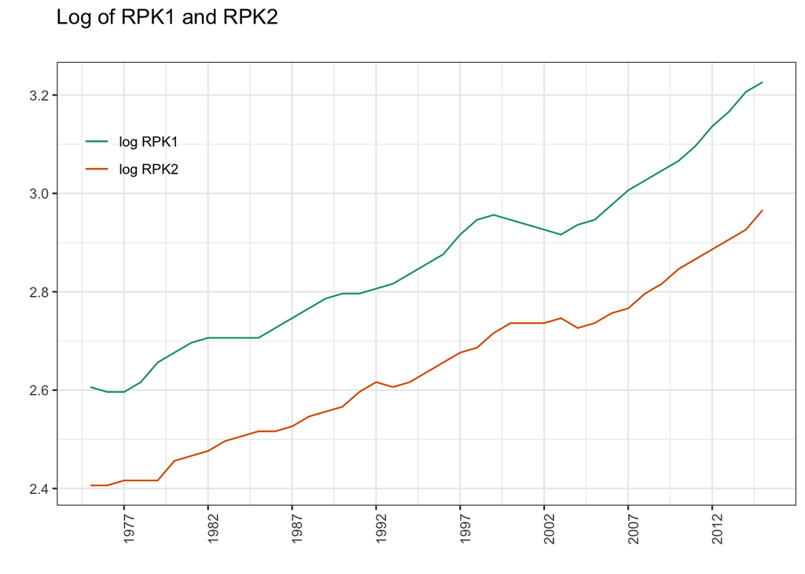

```r
plot_a <- ggplot(data=revenue, aes(x=YEAR)) +
  geom_line(aes(y=X2,col="log RPK2")) +
  geom_line(aes(y=X1,col="log RPK1")) +
  labs(x = "", y = "", title = "Log of RPK1 and RPK2",
       subtitle = ("")) +
    scale_x_date(date_breaks = "5 year", date_labels = "%Y") +
  theme_bw() +
  theme(axis.text.x = element_text(angle = 90, hjust = 1),
        legend.position = c(.1, .8),
        legend.background = element_rect(fill = "transparent")) +
  scale_color_brewer(name= NULL, palette = "Dark2")
plot_a
```

On the other hand, the first differences, which here can be interpreted as annual growth rates, seem stationary because they fluctuate around a constant mean.

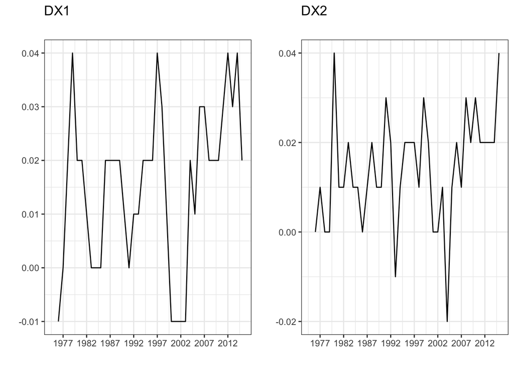

```r
plot_b <- ggplot(data=revenue, aes(x=YEAR)) +
  geom_line(aes(y=DX1)) +
  labs(x = "", y = "", title = "DX1",
       subtitle = ("")) +
    scale_x_date(date_breaks = "5 year", date_labels = "%Y") +
  theme_bw()
plot_c <- ggplot(data=revenue, aes(x=YEAR)) +
  geom_line(aes(y=DX2)) +
  labs(x = "", y = "", title = "DX2",
       subtitle = ("")) +
    scale_x_date(date_breaks = "5 year", date_labels = "%Y") +
  theme_bw()
grid.arrange(plot_b,plot_c, nrow = 1)
```

**To save notation, we use $y_t$ for the logs of each of the series.**

**1. First evaluation step: Check for stationarity**

One of the main R packages for time series modeling is [tseries](https://cran.r-project.org/web/packages/tseries/tseries.pdf)

The R fucntion [adf.test()](https://nwfsc-timeseries.github.io/atsa-labs/sec-boxjenkins-aug-dickey-fuller.html) performs the Augmented Dickey-Fuller test for the null hypothesis of a unit root of a univarate time series x (equivalently, x is a non-stationary time series).

```r
# Set k=1 for the Dickey Fuller test with first lag.
adf.test(revenue$X1,k=1) # contains a unit-root
```

```
##
##  Augmented Dickey-Fuller Test
##
## data:  revenue$X1
## Dickey-Fuller = -2.7644, Lag order = 1, p-value = 0.2729
## alternative hypothesis: stationary
```

```r
adf.test(revenue$X2,k=1) # contains a unit-root
```

```
##
##  Augmented Dickey-Fuller Test
##
## data:  revenue$X2
## Dickey-Fuller = -1.2074, Lag order = 1, p-value = 0.8853
## alternative hypothesis: stationary
```

The ur.df() Augmented Dickey-Fuller test in the urca package gives us a bit more information on and control over the test. he ur.df() function allows us to specify whether to test stationarity around a zero-mean with no trend, around a non-zero mean with no trend, or around a trend with an intercept. This can be useful when we know that our data have no trend, for example if you have removed the trend already. ur.df() allows us to specify the lags or select them using model selection.

In the ADF test equation, we include a constant $(\alpha)$, a deterministic trend term $\beta t$, and a single lag of $\Delta X1_t$

```r
# Set k=1 for the Dickey Fuller test with first lag.
test <- urca::ur.df(na.omit(revenue$X1), type = "trend", lags = 1)
summary(test)
```

```
##
## ###############################################
## # Augmented Dickey-Fuller Test Unit Root Test #
## ###############################################
##
## Test regression trend
##
##
## Call:
## lm(formula = z.diff ~ z.lag.1 + 1 + tt + z.diff.lag)
##
## Residuals:
##       Min        1Q    Median        3Q       Max
## -0.019123 -0.006006 -0.001421  0.004739  0.022106
##
## Coefficients:
##               Estimate Std. Error t value Pr(>|t|)
## (Intercept)  0.4704469  0.1682887   2.795  0.00836 **
## z.lag.1     -0.1814847  0.0656510  -2.764  0.00904 **
## tt           0.0025452  0.0009043   2.815  0.00796 **
## z.diff.lag   0.7606219  0.1342284   5.667 2.12e-06 ***
## ---
## Signif. codes:  0 '***' 0.001 '**' 0.01 '*' 0.05 '.' 0.1 ' ' 1
##
## Residual standard error: 0.01036 on 35 degrees of freedom
## Multiple R-squared:  0.5137, Adjusted R-squared:  0.472
## F-statistic: 12.32 on 3 and 35 DF,  p-value: 1.174e-05
##
##
## Value of test-statistic is: -2.7644 5.2777 3.962
##
## Critical values for test statistics:
##       1pct  5pct 10pct
## tau3 -4.15 -3.50 -3.18
## phi2  7.02  5.13  4.31
## phi3  9.31  6.73  5.61
```

```r
# The intercept and tt estimates indicate where there is a non-zero level (intercept) or linear trend (tt)
```

$$\Delta X_{1,t} = \alpha + \beta t + \rho X_{1,t-1} + \gamma \Delta X_{1,t-1} + \epsilon_t$$
Here we can see that $\hat {\rho} = -0.181$ with SE = 0.065 and the value of ADF test-statistic is: -2.7644.

We do the same for $\Delta X_{2,t} = \alpha + \beta t + \rho X_{12t-1} + \gamma \Delta X_{2,t-1} + \epsilon_t$

```r
# Set k=1 for the Dickey Fuller test with first lag.
test <- urca::ur.df(na.omit(revenue$X2), type = "trend", lags = 1)
summary(test)
```

```
##
## ###############################################
## # Augmented Dickey-Fuller Test Unit Root Test #
## ###############################################
##
## Test regression trend
##
##
## Call:
## lm(formula = z.diff ~ z.lag.1 + 1 + tt + z.diff.lag)
##
## Residuals:
##       Min        1Q    Median        3Q       Max
## -0.035897 -0.004838 -0.000094  0.004530  0.029455
##
## Coefficients:
##              Estimate Std. Error t value Pr(>|t|)
## (Intercept)  0.363125   0.294549   1.233    0.226
## z.lag.1     -0.150500   0.124649  -1.207    0.235
## tt           0.002214   0.001627   1.361    0.182
## z.diff.lag   0.187349   0.185459   1.010    0.319
##
## Residual standard error: 0.01206 on 35 degrees of freedom
## Multiple R-squared:  0.1154, Adjusted R-squared:  0.03958
## F-statistic: 1.522 on 3 and 35 DF,  p-value: 0.2259
##
##
## Value of test-statistic is: -1.2074 7.0053 1.8301
##
## Critical values for test statistics:
##       1pct  5pct 10pct
## tau3 -4.15 -3.50 -3.18
## phi2  7.02  5.13  4.31
## phi3  9.31  6.73  5.61
```

```r
# The intercept and tt estimates indicate where there is a non-zero level (intercept) or linear trend (tt)
```

Here we can see that $\hat {\rho} = -0.150$ with SE = 0.124 and the value of ADF test-statistic is: -1.207.

In summary:

> As both ADF t values are larger than the critical value -3.5 X1 and X2 are not stationary.

**Now let’s test the first difference DX1 and DX2**

```r
# Set k=0 for the Dickey Fuller test.
# Notice that adf.test does not take NA values
adf.test(na.omit(revenue$DX1),k=0) # stationary
```

```
##
##  Augmented Dickey-Fuller Test
##
## data:  na.omit(revenue$DX1)
## Dickey-Fuller = -3.1556, Lag order = 0, p-value = 0.1199
## alternative hypothesis: stationary
```

```r
adf.test(na.omit(revenue$DX2),k=0) # stationary
```

```
##
##  Augmented Dickey-Fuller Test
##
## data:  na.omit(revenue$DX2)
## Dickey-Fuller = -5.2357, Lag order = 0, p-value = 0.01
## alternative hypothesis: stationary
```

When we analyze the growth rates, there is no reason to add any deterministic trend in the test regression.

- Let $y_t$ denote either $\Delta X1$ or $\Delta X2$ with NO trend $\beta t=0$ noticed by visual inspection.
- ADF: $\Delta y_t = \alpha + \rho y_{t-1} + \gamma \Delta y_{t-1} +\epsilon_t$
- t-value of $\hat \rho$: $t=-3.15$ for $X1_t$ and $t=-5.23$ for $X2_t$

And now, the t-ratios in the Dickey-Fuller test become $t_{\Delta X1}=-3.15$ and $t_{\Delta X2}=-5.23$, respectively.

**2. Check for causality**

Next, we investigate if the two series are mutually linked. For that purpose we estimate two autoregressive distributed lag models, one for the growth rates of X1 (DX1) and the other for those of X2 (DX2).

We include two lags of each, and in the table you see the estimated coefficients, their t-statistics and the associated p-values.

We estimate the two following regressions:

$$\Delta X_{1,t} = \alpha + \beta_1 \Delta X_{1,t-1} + \beta_2 \Delta X_{1,t-2} + \gamma_1 \Delta X_{2,t-1} +\gamma_2 \Delta X_{1,t-2} + \epsilon_t \\
\Delta X_{2,t} = \alpha + \beta_1 \Delta X_{1,t-1} + \beta_2 \Delta X_{1,t-2} + \gamma_1 \Delta X_{2,t-1} +\gamma_2 \Delta X_{1,t-2} + \epsilon_t$$

```r
lm1 <- lm(DX1 ~ lag(DX1,1) + lag(DX1,2) + lag(DX2,1) + lag(DX2,2), data=revenue)
lm2 <- lm(DX2 ~ lag(DX1,1) + lag(DX1,2) + lag(DX2,1) + lag(DX2,2), data=revenue)
summ(lm1,digits = 2)
```

| Observations | 38 (3 missing obs. deleted) |
| --- | --- |
| Dependent variable | DX1 |
| Type | OLS linear regression |

| F(4,33) | 7.51 |
| --- | --- |
| R² | 0.48 |
| Adj. R² | 0.41 |

|  | Est. | S.E. | t val. | p |
| --- | --- | --- | --- | --- |
| (Intercept) | 0.01 | 0.00 | 1.84 | 0.07 |
| lag(DX1, 1) | 0.87 | 0.18 | 4.96 | 0.00 |
| lag(DX1, 2) | -0.42 | 0.21 | -2.02 | 0.05 |
| lag(DX2, 1) | 0.35 | 0.20 | 1.74 | 0.09 |
| lag(DX2, 2) | -0.19 | 0.15 | -1.27 | 0.21 |

Standard errors: OLS

```r
summ(lm2,digits = 2)
```

| Observations | 38 (3 missing obs. deleted) |
| --- | --- |
| Dependent variable | DX2 |
| Type | OLS linear regression |

| F(4,33) | 10.89 |
| --- | --- |
| R² | 0.57 |
| Adj. R² | 0.52 |

|  | Est. | S.E. | t val. | p |
| --- | --- | --- | --- | --- |
| (Intercept) | 0.01 | 0.00 | 2.86 | 0.01 |
| lag(DX1, 1) | 0.18 | 0.14 | 1.29 | 0.21 |
| lag(DX1, 2) | 0.61 | 0.17 | 3.68 | 0.00 |
| lag(DX2, 1) | -0.29 | 0.16 | -1.81 | 0.08 |
| lag(DX2, 2) | -0.13 | 0.12 | -1.05 | 0.30 |

Standard errors: OLS

For $\Delta X_{1,t} = \alpha + \beta_1 \Delta X_{1,t-1} + \beta_2 \Delta X_{1,t-2} + \gamma_1 \Delta X_{2,t-1} +\gamma_2 \Delta X_{1,t-2} + \epsilon_t$ we have:

The null hypothesis that $H_0:\Delta X_{2,t}$ is not Granger causal for $\Delta X_{1,t}$, that is $H_0:\gamma_1=\gamma_2=0$

We can see from the results for the first regression that the p-values for the coefficients for lags of $\Delta X_{2,t}$ $t_{\gamma_1}=1.74$ and $t_{\gamma_2}=-1.27$.

For a joint test (F-test) $F = \frac{(R_1^2 - R_0^2)/g}{(1-R_1^2)/(n-k)} \sim F_{(g,n-k)}$ so we need to model under the null $H_0:\gamma_1=\gamma_2=0 \rightarrow \Delta X_{1,t} = \alpha + \beta_1 \Delta X_{1,t-1} + \beta_2 \Delta X_{1,t-2} + \epsilon_t$.

```r
lm0 <- lm(DX1 ~ lag(DX1,1) + lag(DX1,2), data=revenue) # Restricted mode
lm1 <- lm(DX1 ~ lag(DX1,1) + lag(DX1,2) + lag(DX2,1) + lag(DX2,2), data=revenue) # Unrestricted model
# The rest is calculated automatically.
n <- nobs(lm1)
g <- length(lm1$coefficients)-length(lm0$coefficients)
k <- length(lm1$coefficients)
r2_0 <- summary(lm0)$r.squared
r2_1 <- summary(lm1)$r.squared
F_test <- ((r2_1-r2_0)/g)/((1-r2_1)/(n-k))
F_crit <- qf(0.95,g,(n-k))
print(paste("The F test value is ",round(F_test,3)))
```

```
## [1] "The F test value is  2.15"
```

```r
print(paste("The F critical value at 0.95% is ",round(F_crit,3)))
```

```
## [1] "The F critical value at 0.95% is  3.285"
```

```r
if(F_test<F_crit){
  print(paste("We do not reject H_0 at 0.95%"))
} else {
  print(paste("We reject H_0 at 0.95% in favor of H_1"))
}
```

```
## [1] "We do not reject H_0 at 0.95%"
```

> There’s no indication that DX2 is granger causal for DX1

Now we do the same for $\Delta X_{2,t}$ in the model $\Delta X_{2,t} = \alpha + \beta_1 \Delta X_{1,t-1} + \beta_2 \Delta X_{1,t-2} + \gamma_1 \Delta X_{2,t-1} +\gamma_2 \Delta X_{1,t-2} + \epsilon_t$.

The null hypothesis that $H_0:\Delta X_{1,t}$ is not Granger causal for $\Delta X_{2,t}$, that is $H_0:\beta_1=\beta_2=0$

```r
lm0 <- lm(DX2 ~ lag(DX2,1) + lag(DX2,2), data=revenue) # Restricted mode
lm1 <- lm(DX2 ~ lag(DX1,1) + lag(DX1,2) + lag(DX2,1) + lag(DX2,2), data=revenue) # Unrestricted model
# The rest is calculated automatically.
n <- nobs(lm1)
g <- length(lm1$coefficients)-length(lm0$coefficients)
k <- length(lm1$coefficients)
r2_0 <- summary(lm0)$r.squared
r2_1 <- summary(lm1)$r.squared
F_test <- ((r2_1-r2_0)/g)/((1-r2_1)/(n-k))
F_crit <- qf(0.95,g,(n-k))
print(paste("The F test value is ",round(F_test,3)))
```

```
## [1] "The F test value is  20.978"
```

```r
print(paste("The F critical value at 0.95% is ",round(F_crit,3)))
```

```
## [1] "The F critical value at 0.95% is  3.285"
```

```r
if(F_test<F_crit){
  print(paste("We do not reject H_0 at 0.95%"))
} else {
  print(paste("We reject H_0 at 0.95% in favor of H_1"))
}
```

```
## [1] "We reject H_0 at 0.95% in favor of H_1"
```

> There’s evidence that DX1 is granger causal for DX2

Clearly, growth rates of X1 (DX1) can be predicted by their own past, and some of that past is also informative for DX2. So **airline one is Granger causal for airline two, but not the other way around.** And note that you need formal tests to establish this result, as the graphs are in no way informative in this respect.

**2. Check for cointegration**

Next, let us investigate whether the two series are cointegrated. The linear regression of X2 on X1 gives the **candidate long-run equilibrium relation with a slope coefficient of 0.92.**

```r
lm3 <- lm(X2 ~ X1, data=revenue)
summ(lm3, digits = 2)
```

| Observations | 41 |
| --- | --- |
| Dependent variable | X2 |
| Type | OLS linear regression |

| F(1,39) | 2777.98 |
| --- | --- |
| R² | 0.99 |
| Adj. R² | 0.99 |

|  | Est. | S.E. | t val. | p |
| --- | --- | --- | --- | --- |
| (Intercept) | 0.01 | 0.05 | 0.23 | 0.82 |
| X1 | 0.92 | 0.02 | 52.71 | 0.00 |

Standard errors: OLS

$$\text{Step 1 OLS : } X_{2,t}= 0.01 +0.92 X_{1,t} + e_t$$

```r
# We add the residuals of lm3 into the dataset
revenue <- revenue %>% mutate(lm3.res = resid(lm3))
# Perform ADF on the residuals.
# Set k=0 for the Dickey Fuller test.
test <- urca::ur.df(na.omit(revenue$lm3.res), type = "none", lags = 1)
summary(test)
```

```
##
## ###############################################
## # Augmented Dickey-Fuller Test Unit Root Test #
## ###############################################
##
## Test regression none
##
##
## Call:
## lm(formula = z.diff ~ z.lag.1 - 1 + z.diff.lag)
##
## Residuals:
##       Min        1Q    Median        3Q       Max
## -0.031330 -0.010599  0.000282  0.010458  0.033622
##
## Coefficients:
##            Estimate Std. Error t value Pr(>|t|)
## z.lag.1     -0.4962     0.1394  -3.558  0.00104 **
## z.diff.lag   0.3043     0.1637   1.859  0.07104 .
## ---
## Signif. codes:  0 '***' 0.001 '**' 0.01 '*' 0.05 '.' 0.1 ' ' 1
##
## Residual standard error: 0.01456 on 37 degrees of freedom
## Multiple R-squared:  0.2556, Adjusted R-squared:  0.2154
## F-statistic: 6.353 on 2 and 37 DF,  p-value: 0.004249
##
##
## Value of test-statistic is: -3.5583
##
## Critical values for test statistics:
##       1pct  5pct 10pct
## tau1 -2.62 -1.95 -1.61
```

```r
# The intercept and tt estimates indicate where there is a non-zero level (intercept) or linear trend (tt)
```

$$\text{Step 2 ADF : } \Delta e_t= 0.00 -0.50 e_{t-1} + 0.30 \Delta e_{t-1} + res_t$$

The ADF test is based on the estimate of $-0.50$ for the coefficient of e in period $t-1$ in the relevant auxiliary regression. And it equals $t=-3.558$. And as this is smaller than the 5% critical value $-3.4$, we can conclude that the residuals from the regression in step one are stationary. **And thus, that X1 and X2 are co-integrated.**

> As the t value is smaller than the critical value -3.4, e_t are stationary so X1 and X2 are co-integrated.

When we now include the **error correction term** in the model for the growth rates of $X1$, we get an adjustment parameter of $0.46$. And when we include it in the model for the growth rates of $X2$, we get $-0.45$.

- ECM (after removing insignificant coefficients) and susbtituing $\text{Step 1 OLS removing insignificant coefficients: } X_{2,t}=0.92 X_{1,t}$.

$$\Delta X_{1,t} = 0.00 + 1.02 \Delta X_{1,t-1} + 0.46(X_{2,t-1}-0.92X_{1,t-1}) + e_{1,t} \\
\Delta X_{2,t} = 0.02 - 0.45 (X_{2,t-1}-0.92X_{1,t-1}) + e_{2,t}$$

The signs of these parameters imply that X1 and X2 cannot deviate too much from their equilibrium. For example, suppose that there is a positive deviation in period $t-1$. This will have an increasing effect on $X1_t$ in period t and a decreasing effect on $X2_t$. And as a result, the deviation from equilibrium is expected to decline in period t. Note also that deviations from the equilibrium are corrected by changes in both $X1_t$ and $X2_t$

$$\begin{split}
\text{If } D_{t-1} = X_{2,t-1}-0.92X_{1,t-1} \geq 0 \text{ is positive, then }\\
0.46 >0 \rightarrow X_{1,t}\uparrow \rightarrow D_t= X_{2,t-1}-0.92X_{1,t-1} \downarrow \\
-0.45 < 0 \rightarrow X_{2,t}\downarrow \rightarrow D_t= X_{2,t-1}-0.92X_{1,t-1} \downarrow \\
\text{Error correction mechanism acts on both variables}
\end{split}$$

**3. ECM: Check for serial correlation and normality**

Let us finally employ diagnostic tests on the residual autocorrelation and normality. The error correction models were as follows.

```r
ecm1 <- lm(DX1 ~ lag(DX1,1) + I(lag(X2,1)-0.92*lag(X1,1)), data=revenue)
ecm2 <- lm(DX2 ~  I(lag(X2,1)-0.92*lag(X1,1)), data=revenue)
summ(ecm1, digits = 3)
```

| Observations | 39 (2 missing obs. deleted) |
| --- | --- |
| Dependent variable | DX1 |
| Type | OLS linear regression |

| F(2,36) | 27.938 |
| --- | --- |
| R² | 0.608 |
| Adj. R² | 0.586 |

|  | Est. | S.E. | t val. | p |
| --- | --- | --- | --- | --- |
| (Intercept) | -0.004 | 0.003 | -1.240 | 0.223 |
| lag(DX1, 1) | 1.022 | 0.138 | 7.403 | 0.000 |
| I(lag(X2, 1) - 0.92 * lag(X1, 1)) | 0.463 | 0.107 | 4.335 | 0.000 |

Standard errors: OLS

```r
summ(ecm2, digits = 3)
```

| Observations | 40 (1 missing obs. deleted) |
| --- | --- |
| Dependent variable | DX2 |
| Type | OLS linear regression |

| F(1,38) | 33.604 |
| --- | --- |
| R² | 0.469 |
| Adj. R² | 0.455 |

|  | Est. | S.E. | t val. | p |
| --- | --- | --- | --- | --- |
| (Intercept) | 0.018 | 0.002 | 11.285 | 0.000 |
| I(lag(X2, 1) - 0.92 * lag(X1, 1)) | -0.447 | 0.077 | -5.797 | 0.000 |

Standard errors: OLS

- ECM models for log(RPK) of airline companies 1 and 2 (n = 39):

$$\Delta X_{1,t} = 0.00 + 1.02 \Delta X_{1,t-1} + 0.46(X_{2,t-1}-0.92X_{1,t-1}) + e_{1,t} \\
\Delta X_{2,t} = 0.02 - 0.45 (X_{2,t-1}-0.92X_{1,t-1}) + e_{2,t}$$

The Jarque-Bera test statistics for normality show that normality of the residuals is not rejected for both X1 and X2. And also the Breusch-Godfrey test values for first-order residual autocorrelation are not significant.

```r
# Null of normality
jarque.bera.test(ecm1$residuals) # Null: Normality not rejected
```

```
##
##  Jarque Bera Test
##
## data:  ecm1$residuals
## X-squared = 0.38543, df = 2, p-value = 0.8247
```

```r
jarque.bera.test(ecm2$residuals) # Null: Normality not rejected
```

```
##
##  Jarque Bera Test
##
## data:  ecm2$residuals
## X-squared = 1.8226, df = 2, p-value = 0.402
```

$$\text{Jarque-Bera test : } JB_1 = 0.38 < 6, JB_2 = 1.82 < 6. \text{ Normality not rejected}$$
The function bgtest performs the Breusch-Godfrey test for higher-order serial correlation.

Under the null hypothesis of no autocorrelation, this test has a chi-square distribution with R degrees of freedom

```r
bgtest(ecm1, order = 1) # Null: No autocorrelation not rejected
```

```
##
##  Breusch-Godfrey test for serial correlation of order up to 1
##
## data:  ecm1
## LM test = 0.29898, df = 1, p-value = 0.5845
```

```r
bgtest(ecm2, order = 1) # Null: No autocorrelation not rejected
```

```
##
##  Breusch-Godfrey test for serial correlation of order up to 1
##
## data:  ecm2
## LM test = 1.2399, df = 1, p-value = 0.2655
```

$$\text{Breusch-Godfrey test (1 lag) : } BG_1 = 0.29 < 3.9, BG_2 = 1.23 < 3.9 \text{ No autocorrelation}$$

$$ACF : 2/\sqrt{n}=2/\sqrt{39}=0.32$$

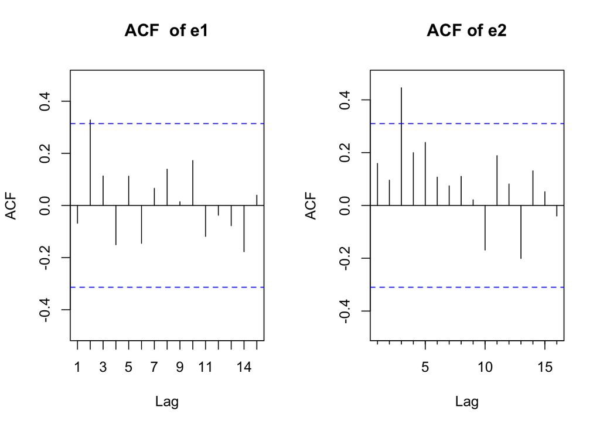

```r
par(mfrow=c(1,2))
Acf(ecm1$residuals,main = "ACF  of e1")
Acf(ecm2$residuals,main = "ACF of e2")
```

[^1]: El Colegio de México, diego.lopez@colmex.mx